# Rolling-window benchmark, redone with cuplyr

Redo of https://roald-arboel.com/blog/posts/2024/10/03/Benchmark-rolling/ with cuplyr added as one more entry in every statistic panel, and polars and DuckDB added as further entries (Theo, 2026-10-25) at their default threads and at one thread. The rendered report is published at /home/theo/cuplr/scratchpad/benchmarks/rolling/rolling-window.html. Produced by this document (`bench/rolling-window.qmd`; helpers in `bench/rolling-lib.R`, installs in `bench/install-deps.R`): the code that produces every number, table and figure is in the same file as the prose, and every number in the prose is computed from the results. Raw data, written to /home/theo/cuplr/scratchpad/benchmarks/rolling on every render: `timings.csv`, `correctness.csv`, `extension.csv`, `versions.csv`, `memory-breakdown.csv`, `memory-finding.csv`, `skipped.csv`, `engine-threads.csv`, `cores.csv` (the core-placement samples).

**Run configuration:** cell budget 20 s, probe limit 60 s, `times` 20, `times_custom` 5, `ext_times` 10. These are the defaults of the document, with no parameter overridden. See “How to render” at the end for the command.

Wall time of the timing chunks, which hold the GPU: **20 min 16 s** (bench-main 13 min 24 s, bench-overhead 29 s, bench-ext 39 s, bench-engines 5 min 16 s, bench-memory 1 s, bench-fence 2 s, bench-runstats-shift 8 s, bench-cores 15 s; the elapsed times of the complete cold render from 20:35 to 20:55 on 2026-10-26, which produced every cached result). Every number below is computed in this document from those results.

## Read this first: what the numbers are

**What cuplyr’s number is.** The cuplyr timing is the **computation on a table that is already on the GPU**: `res <- compute(mutate(gt, r = roll_mean(x, n)))` followed by `gpu_sync()` as a fence, with `gt <- tbl_gpu(df)` built once outside timing. By decision (Theo, 2026-10-21) it contains **no upload and no `collect()`**. The post’s CPU packages operate on an R vector already in memory, and polars and DuckDB on their own in-engine copy of the data (next paragraph), so every entry times the computation only. A real pipeline that starts and ends in R would also pay the PCIe transfers that are excluded here (not measured in this study). Every cuplyr entry that is timed is computation only. Cells that run on the CPU fallback (download, an R loop, re-upload) are not timed: `cuplyr` (median, all three widths). The median table and plot carry a note instead of a number for cuplyr.

**What the CPU numbers are: measured thread behaviour, not settings.** Package thread settings do not say what a call did, so each multi-thread-capable entry (data.table, RcppRoll, roll, and the engines polars and DuckDB) was timed twice, at its default setting and with its threads set to one (entries labelled `(1 thread)`), and the “Threads actually used” section reports both. The result:

- **RcppRoll runs on 24 OpenMP threads by default** (`RcppRoll::roll_threads()` = 24) and scales with them: 9-15x slower at one thread for every statistic at w=101.
- **data.table’s `frollmean/sum/min/max/sd` and its `by=` evaluation ran effectively on one thread** (default vs `setDTthreads(1)` within 3.4%), although `getDTthreads()` is 12. Only `frollmedian` (2.3x), `frollsum(algo = "exact")` (4.9x) and `frollapply` (1.7x) scale.
- **roll ran effectively on one thread** for every statistic (1-thread vs default within 2.2% at w=101), although RcppParallel reports 24 available threads. (`roll.so` also imports seven OpenMP runtime symbols (`GOMP*`, `omp_*`), which `setThreadOptions()` does not govern; the default online vector workers used here are sequential loops, and only roll’s offline workers are RcppParallel workers, so the one-thread reading holds.)
- RollingWindow, slider, zoo and runner were not given a thread control. Their compiled code imports no OpenMP or TBB runtime symbol (`nm -D --undefined-only` on the installed shared object, run by this document) and runstats is pure R. I treat them as single-threaded; that is a static check, not a timing.
- polars does not scale on any statistic (one-thread / default median ratio 0.94-1.06 at w=101; 1.49 grouped (scales weakly); 1.01 at 1e7 rows (does not scale)); it ran with 24 threads by default and 1 at one, as read back from the engine (`engine-threads.csv`).
- DuckDB scales on every statistic (one-thread / default median ratio 2.97-8.24 at w=101; 5.76 grouped (scales); 4.03 at 1e7 rows (scales)); it ran with 24 threads by default and 1 at one, as read back from the engine (`engine-threads.csv`).

So there is no blanket “GPU against N CPU threads” framing in this report: the comparison is to the per-entry thread behaviour above. Medians are reported with their spread (IQR in the tables, all samples in `timings.csv`). No headline speedup is claimed.

**What the polars and DuckDB numbers are.** polars and DuckDB follow the same rule as cuplyr: each engine gets its data once, outside timing, and the timed call is only the rolling computation, to a result that stays inside the engine. For polars the timed call is `pdf$with_columns(<rolling expression>$alias("r"))` on a polars DataFrame built once (eager, so the expression is evaluated when the call returns; `over("g")` when grouped), and the result is never converted to R inside timing. For DuckDB it is one `CREATE TEMP TABLE rw_out AS SELECT i, <guarded window aggregate> AS r FROM rw_x WINDOW w AS (ORDER BY i ROWS BETWEEN n - 1 PRECEDING AND CURRENT ROW)` on an in-memory DuckDB table loaded once; the result is materialized inside DuckDB and nothing is fetched into R. The sort that `ORDER BY i` implies is inside the timed query, because SQL has no row order without it. That is “closest to computation only” for DuckDB: fetching the result into R would add a copy that cuplyr’s timing does not have either. Both engines ran at their default threads (polars 24, DuckDB 24, read back from the engine) and at one thread (polars 1, DuckDB 1). The comparison with cuplyr is therefore engine against GPU on in-engine data, not against an R vector.

**What the cuplyr number still includes, per call.** R dispatch of `mutate()`/`compute()`, the AST node builds and schema inference, lowering to C++, the three nodes of an eager window `mutate()` (a window node, a mutate node and a select node), which run as one chain that shares the input column `x` instead of copying it, so only the computed columns and their validity masks are allocated (see “Per-call cost breakdown”), and the fence. The same call on a 1e3-row table, where kernel time is negligible, takes about 1.7 ms for window functions (a plain `mutate(y = x + 1)` takes 0.7 ms). That floor is about 105% of the 1.59 ms measured at 1e6 rows / width 11 and larger than the whole data.table call (1.37 ms). The allocation part grows with the row count and is **inside every 1e6 and 1e7 cuplyr timing** but not in the 1e3-row floor. For comparison, the same call at w=101 on the 1e3-row table, measured the same way for the engines (the median over the five statistics of each statistic’s median; chunk `bench-engines`, samples in `timings.csv`), takes 0.958 ms for polars (0.948 ms at one thread) and 1.86 ms for DuckDB (1.68 ms at one thread). DuckDB’s figure includes the sort that its `ORDER BY i` implies; I did not time that sort separately.

## Method

- Data: `rw_data(n)` (`set.seed(12345)` by default, then `rnorm(n)`) with n = 1e6, no NAs, widths 11 / 101 / 1001, right-aligned, output the same length as the input, `NA` padded. Same functions and arguments as the post (see `rw_functions()` in `bench/rolling-lib.R`), `times` = 20, `times` = 5 for the custom function.
- **Deviation 1, one harness for everyone.** The post used `microbenchmark(times = 20)`, which interleaves expressions and does not force a GC. Here every function (CPU packages, polars, DuckDB and cuplyr) goes through `rw_time()`: untimed warmup calls, then `times` samples; an untimed `gc()` runs before every call with the previous result already dropped; each sample is timed with `microbenchmark::get_nanotime()`. cuplyr is given the `gc()` too: the result of an eager `mutate()`, once dropped, is freed only when R finalizes its pointer (finding F1), and twenty back-to-back 1e7-row calls without it did not run the 12 GB card out of memory in this run, but the dropped results still pile up until a collection. Applying the same `gc()` to everyone keeps the comparison symmetric. Consequence: no GC ever lands inside a timed region, which in the post’s interleaved harness it sometimes did, and deallocation of each result is untimed for every engine (cuplyr’s GPU tables go back to CUDA’s asynchronous memory pool, cuplyr’s default memory resource, with `cudaFreeAsync` inside that untimed `gc()`, and the pool keeps the memory for reuse (no release threshold is set); the CPU packages’ vectors and polars’ DataFrames likewise; DuckDB’s result table is dropped by the untimed `reset`). A test (`tests/testthat/test-bench-F54-harness-extra.R`) pins that `gc()` runs before every call and outside the timed region.
- **Deviation 2, GPU completion.** cuplyr’s API gives no “work finished” guarantee (cuplyr exports `gpu_sync()` (a device-wide wait), but the verbs return once their work is queued). The timed closure ends with `cuplyr::gpu_sync()`, which waits for all queued GPU work (no copy back to the host). The fence adds under 1 ms (chunk `bench-fence` timed the rolling mean at 1e7 rows, w=101, in 6.27 ms with the fence and 5.74 ms without, 10 interleaved pairs, median paired difference 0.533 ms); the call without the fence returns once the work is queued, so it times the launch only, and the difference is the GPU time the fence waits for.
- **Deviation 3, slow cells get fewer samples** (`cell_budget` = 20 s of timed work per cell). Each cell starts with one cold probe call; its duration sets the sample count through `rw_plan_cell()` (`bench/rolling-lib.R`). A cuplyr cell has one more untimed call before that one, the native probe of the fallback check below, so its “cold” call is its second call and it gets one more warm-up call than the CPU packages. The probe call is *not* a recorded sample (unless it alone exceeds `probe_limit` = 60 s, which no cell did); warmup calls (2; 1 above 5 s; 0 above 15 s) and then `k` timed calls follow, and the `note` column of `timings.csv` records exactly this per cell. Every cut is listed in the `times` cuts table.
- **Deviation 4, runstats alignment moved out of timing.** `runstats::RunningMean/RunningSd` return left-aligned windows (the window starts at i; the last `n - 1` values are `NA`). The timed closure returns that raw result and only tags it in place (`attr(out, "rw_align") <- "left"`, plus the window width in `rw_window`, on the local fresh vector: no copy). `rw_normalize()` shifts tagged output to right-aligned, outside timing, before the correctness check. So runstats is timed as the package returns it: mean 13.5 ms, sd 32.0 ms at w=101 in the results tables. Chunk `bench-runstats-shift` timed the same two calls again with the shift inside the call, interleaved with the unshifted calls (20 pairs per statistic; these are that chunk’s own samples, not the tables’). In those pairs the shift adds 3.86 ms to the mean call (8.08 ms unshifted, 11.9 ms shifted) and 3.75 ms to the sd call (34.2 and 37.8 ms), so the shift is a sizeable part of the mean figure. The unshifted figures of that chunk (8.08 and 34.2 ms) are not the tables’ (13.5 and 32.0 ms): the same call took different times in two chunks of this render, which this report does not explain. The tables’ figures are the ones reported; from the side chunk only the paired difference is used.
- **Deviation 5, argument choices the brief left open.** `RcppRoll::roll_medianr(fill = NA)` is used (right-aligned; plain `roll_median` is centred). The custom function is `sum_custom <- function(x) sum(x)`, a naive window sum (my reading of “unoptimised”; I did not have the post’s exact body). Calls: `data.table::frollapply(x, n, sum_custom)` and `zoo::rollapply(x, n, sum_custom, fill = NA, align = "right")`.
- **Single-thread controls.** `data.table (1 thread)` is `setDTthreads(1)` for the cell (restored afterwards); `RcppRoll (1 thread)` is `options(RcppRoll.threads = 1)`; `roll (1 thread)` is `RcppParallel::setThreadOptions(numThreads = 1)` (restored to `"auto"`). The one-thread entry of these three is timed right after its default-thread entry on the same data, through the same harness, and is also checked for correctness. The engines are ordered differently: each whole grid runs once per thread setting (all the DuckDB cells at the default threads, then all at one thread; then the polars grid in one fresh process at the default and in another at one thread), so an engine’s default and one-thread cells are not neighbours. Thread settings as found, before any change: `OMP_NUM_THREADS` unset, `getDTthreads()` 12, `RcppRoll::roll_threads()` 24, `RcppParallel::defaultNumThreads()` 24 (`versions.csv`).
- **Correctness check (not in the post).** Results are computed outside timing, normalized (`as.numeric`, runstats shifted, left-pad with `NA`) and compared with `data.table::froll<stat>` via `all.equal(tolerance = tol)` (tol = 1e-08) plus identical NA positions. cuplyr results are collected for this check only. A cell whose call errors counts as a failure in the table (it does not drop out of the count); there were none.
- **Fallback check.** Every cuplyr cell is probed before it is timed: one untimed call under `options(cuplyr.fallback = "error")` (`rw_native_probe()` in `bench/rolling-lib.R`). A cell whose probe call falls back to the CPU (cuplyr’s “fell back to CPU evaluation” error) is not timed, not checked for correctness and not plotted; it is recorded in the skipped-cells table below and in `skipped.csv`. A probe call that fails for any other reason is not a skip: in the main and extension experiments the cell is recorded as failed (an error row, which counts against the correctness total), and in the overhead, memory and fence chunks it stops the render. Three cells were skipped in this run: `cuplyr` (median, all three widths); they are listed in the table below and in `skipped.csv`. As a second check the timed cells catch `cuplyr_cpu_fallback` conditions: none was raised by a timed cell.
- **polars and DuckDB (F73).** Both are checked against data.table like every other entry, and both go through the same `run_cell()` and `rw_time()` as everything else (cold probe call, budgeted samples, gc before every call). DuckDB: an in-memory database (`shared_home = FALSE`, so nothing is written under the home directory) with the data loaded once into a real table by `dbWriteTable()` (not a re-scanned R data frame); one connection per (thread setting, dataset), with the default or `SET threads = 1`, each loading its dataset once outside timing and closed with `shutdown = TRUE` when its cells are done. A raw `ROWS` frame is partial at the start of the table (and of each group): it holds fewer than `n` rows and DuckDB aggregates them, where data.table gives NA, so the timed SQL guards the aggregate (`CASE WHEN i >= n`, with `row_number() OVER w` when grouped) and returns NULL until the window is full. The plain `CREATE TEMP TABLE` (no `OR REPLACE`) leaves the result inside DuckDB, and the `DROP TABLE` of the previous result runs untimed before every call (the `reset` hook of `run_cell()` and `rw_time()`, the probe call included); a drop inside timing would be an error, because the table would still exist. polars: the thread pool is fixed when polars first loads and is read from the environment variable `POLARS_MAX_THREADS`, so each polars configuration runs in its own fresh R process (`callr`, started by `rw_polars_child()`), with `POLARS_MAX_THREADS` set to one or unset before polars loads. That process puts `params$lib` first on its library path, sources the same `rolling-lib.R` this document sourced (by absolute path), never loads cuplyr (so it holds no CUDA context), runs its cells with the same harness, compares them with `rw_reference()` on the same seeded data and returns plain data frames. For both engines the thread count in effect is read back from the engine (`polars_info()$thread_pool_size`, `current_setting('threads')`), not assumed from the setting: `engine-threads.csv` has them (polars 24 by default and 1 at one thread; DuckDB 24 and 1). The `custom` function has no polars or DuckDB entry (neither applies an R function over windows). No cuplyr CPU-fallback cell is timed, as before.
- cuplyr entries: `cuplyr` is native `roll_<stat>(x, n)` inside `mutate()`; `cuplyr (froll alias)` is `data.table::froll<stat>(x, n)` inside `mutate()` (cuplyr maps it to the same kernel; the alias differed from native by -0.000749 to 0.0333 ms across 15 cells (slower in 14 of them)). There is no cuplyr median entry: `roll_median()` has no cudf kernel in 25.12 and runs through an R loop on collected data, so it is not timed. Custom: n/a (cuplyr cannot apply an arbitrary R function over windows).
- **Comparison words.** Two medians are “level” when they are within 5% of each other, unless their interquartile ranges do not overlap, in which case one is “slightly faster” than the other; outside that band they are “faster” and “slower”. A cost “grows” with the window width when the median at w=1001 is at least 1.5 times the median at w=11 (it “shrinks” at the inverse ratio and is “flat” in between); slider is “growing” above 1.1 times. An entry “scales” with threads at a one-thread over default ratio of at least 1.5, and does not at 1.15 or less. Two figures “agree” within a factor of 1.25 (so do the two pinned CPUs of one kind in chunk `bench-cores`, or that measurement counts as disturbed and none of its figures is quoted); a slow core is measurably slower above 1.2 times; two calls “cost the same” within 10%; a custom function is clearly slower above 10 times its optimized equivalent; the narrow-window call is “mostly call chain” when it is within 25% of the `cumsum` mutate; a peak is “well inside” the card below 25% of its memory. cuplyr’s rank among the entries at their default settings (the one-thread controls are not ranked) is “near the front” when its rank divided by the number of those entries is at most 0.25, “near the back” at 0.75 or more and “mid-pack” in between; the runstats alignment shift is “a sizeable part” of the mean figure when it adds more than 10% to it.

### Skipped cells (cuplyr cells that run on the CPU fallback)

These cells were not timed; the reason is the message of the probe call. None of them has a row in `timings.csv` or `correctness.csv`; they are listed in `skipped.csv`.

| chunk | stat | fn | width | reason |
| --- | --- | --- | --- | --- |
| bench-main | median | cuplyr | 11 | cuplyr: mutate() fell back to CPU evaluation for: mutate() |
| bench-main | median | cuplyr | 101 | cuplyr: mutate() fell back to CPU evaluation for: mutate() |
| bench-main | median | cuplyr | 1001 | cuplyr: mutate() fell back to CPU evaluation for: mutate() |

## Threads actually used

Default vs one thread, median ms (IQR) over the samples of each entry (20 per cell for the 1e6-row rows, 5 for `frollapply`; 10 for the extension rows), width 101. `ratio` = one-thread median / default median; “scales” says whether the entry used the extra threads (ratio >= 1.5: yes; <= 1.15: no). The `default_threads` column is what the package reports, not what the call used; for polars and DuckDB it is the count read back from the engine in the process that ran the cells.

| experiment | statistic | entry | default_threads | default_ms | one_thread_ms | ratio | scales |
| --- | --- | --- | --- | --- | --- | --- | --- |
| 1e6 rows, w=101 | mean | data.table | 12 (setDTthreads) | 1.37 (1.36-1.38) | 1.37 (1.36-1.38) | 1.00 | no |
| 1e6 rows, w=101 | sum | data.table | 12 (setDTthreads) | 1.34 (1.34-1.37) | 1.36 (1.34-1.37) | 1.01 | no |
| 1e6 rows, w=101 | min | data.table | 12 (setDTthreads) | 2.32 (2.30-2.36) | 2.33 (2.28-2.36) | 1.00 | no |
| 1e6 rows, w=101 | max | data.table | 12 (setDTthreads) | 2.37 (2.33-2.37) | 2.33 (2.29-2.34) | 0.98 | no |
| 1e6 rows, w=101 | sd | data.table | 12 (setDTthreads) | 10.6 (10.6-10.8) | 10.6 (10.5-10.6) | 1.00 | no |
| 1e6 rows, w=101 | median | data.table | 12 (setDTthreads) | 19.2 (19.0-19.3) | 44.7 (44.4-45.0) | 2.34 | yes (2.3x slower at 1 thread) |
| 1e6 rows, w=101 | sum | data.table (exact) | 12 (setDTthreads) | 7.77 (7.74-7.80) | 38.3 (38.2-38.9) | 4.93 | yes (4.9x slower at 1 thread) |
| 1e6 rows, w=101 | custom | data.table::frollapply | 12 (setDTthreads) | 1260 (1260-1280) | 2090 (2090-2100) | 1.66 | yes (1.7x slower at 1 thread) |
| 1e6 rows, w=101 | mean | DuckDB | 24 (current_setting) | 32.5 (31.5-33.5) | 100 (99.3-101) | 3.09 | yes (3.1x slower at 1 thread) |
| 1e6 rows, w=101 | sum | DuckDB | 24 (current_setting) | 31.9 (31.5-33.5) | 94.8 (94.5-95.7) | 2.97 | yes (3.0x slower at 1 thread) |
| 1e6 rows, w=101 | min | DuckDB | 24 (current_setting) | 32.9 (32.0-33.9) | 107 (105-107) | 3.26 | yes (3.3x slower at 1 thread) |
| 1e6 rows, w=101 | max | DuckDB | 24 (current_setting) | 32.1 (31.6-33.1) | 107 (105-107) | 3.32 | yes (3.3x slower at 1 thread) |
| 1e6 rows, w=101 | sd | DuckDB | 24 (current_setting) | 33.2 (31.9-34.1) | 159 (158-160) | 4.80 | yes (4.8x slower at 1 thread) |
| 1e6 rows, w=101 | median | DuckDB | 24 (current_setting) | 43.9 (41.2-45.5) | 361 (357-364) | 8.24 | yes (8.2x slower at 1 thread) |
| 1e6 rows, w=101 | mean | polars | 24 (polars_info) | 6.17 (6.03-7.01) | 6.12 (5.92-6.51) | 0.99 | no |
| 1e6 rows, w=101 | sum | polars | 24 (polars_info) | 5.88 (5.73-6.18) | 5.95 (5.67-7.08) | 1.01 | no |
| 1e6 rows, w=101 | min | polars | 24 (polars_info) | 13.7 (13.6-13.8) | 13.7 (13.6-14.0) | 1.00 | no |
| 1e6 rows, w=101 | max | polars | 24 (polars_info) | 13.8 (13.6-13.9) | 13.7 (13.5-14.0) | 1.00 | no |
| 1e6 rows, w=101 | sd | polars | 24 (polars_info) | 12.9 (12.6-13.1) | 13.6 (12.6-17.2) | 1.06 | no |
| 1e6 rows, w=101 | median | polars | 24 (polars_info) | 48.2 (47.8-49.2) | 45.2 (44.8-47.4) | 0.94 | no |
| 1e6 rows, w=101 | mean | RcppRoll | 24 (OpenMP) | 0.870 (0.812-0.943) | 7.82 (7.74-7.84) | 8.99 | yes (9.0x slower at 1 thread) |
| 1e6 rows, w=101 | sum | RcppRoll | 24 (OpenMP) | 0.831 (0.806-0.890) | 7.70 (7.63-7.73) | 9.27 | yes (9.3x slower at 1 thread) |
| 1e6 rows, w=101 | min | RcppRoll | 24 (OpenMP) | 0.957 (0.941-0.996) | 11.4 (11.1-11.5) | 11.94 | yes (11.9x slower at 1 thread) |
| 1e6 rows, w=101 | max | RcppRoll | 24 (OpenMP) | 0.985 (0.946-1.01) | 11.2 (11.1-11.3) | 11.35 | yes (11.3x slower at 1 thread) |
| 1e6 rows, w=101 | sd | RcppRoll | 24 (OpenMP) | 1.05 (1.03-1.06) | 10.1 (9.90-10.3) | 9.64 | yes (9.6x slower at 1 thread) |
| 1e6 rows, w=101 | median | RcppRoll | 24 (OpenMP) | 4.35 (4.24-4.53) | 64.5 (64.1-65.3) | 14.82 | yes (14.8x slower at 1 thread) |
| 1e6 rows, w=101 | mean | roll | 24 (RcppParallel) | 4.05 (4.03-4.08) | 4.10 (3.98-4.17) | 1.01 | no |
| 1e6 rows, w=101 | sum | roll | 24 (RcppParallel) | 3.10 (3.08-3.15) | 3.11 (3.08-3.14) | 1.00 | no |
| 1e6 rows, w=101 | min | roll | 24 (RcppParallel) | 10.4 (10.3-10.6) | 10.6 (10.5-10.8) | 1.02 | no |
| 1e6 rows, w=101 | max | roll | 24 (RcppParallel) | 10.4 (10.3-10.5) | 10.6 (10.5-10.7) | 1.02 | no |
| 1e6 rows, w=101 | sd | roll | 24 (RcppParallel) | 23.2 (22.7-23.4) | 22.9 (22.8-23.0) | 0.99 | no |
| 1e6 rows, w=101 | median | roll | 24 (RcppParallel) | 203 (193-206) | 207 (201-210) | 1.02 | no |
| grouped mean, w=101 | mean | data.table (by = g) | 12 (setDTthreads) | 29.8 (29.4-30.3) | 28.8 (28.6-29.1) | 0.97 | no |
| grouped mean, w=101 | mean | DuckDB | 24 (current_setting) | 29.6 (29.0-29.9) | 170 (170-171) | 5.76 | yes (5.8x slower at 1 thread) |
| grouped mean, w=101 | mean | polars | 24 (polars_info) | 12.9 (12.7-13.7) | 19.2 (19.1-19.3) | 1.49 | weakly |
| 1e7 ungrouped mean, w=101 | mean | data.table | 12 (setDTthreads) | 18.2 (18.2-18.2) | 18.3 (18.2-18.4) | 1.00 | no |
| 1e7 ungrouped mean, w=101 | mean | DuckDB | 24 (current_setting) | 262 (254-266) | 1060 (1050-1060) | 4.03 | yes (4.0x slower at 1 thread) |
| 1e7 ungrouped mean, w=101 | mean | polars | 24 (polars_info) | 49.5 (49.1-50.3) | 49.9 (49.3-50.3) | 1.01 | no |
| 1e7 ungrouped mean, w=101 | mean | RcppRoll | 24 (OpenMP) | 11.6 (11.5-11.9) | 81.9 (81.7-82.3) | 7.07 | yes (7.1x slower at 1 thread) |
| 1e7 ungrouped mean, w=101 | mean | roll | 24 (RcppParallel) | 48.3 (48.0-48.7) | 48.5 (48.2-48.8) | 1.00 | no |

Reading it:

- RcppRoll scales on every statistic (9.0-14.8x slower at one thread at w=101; 7.1x at 1e7 rows). Its 24-thread numbers are what the “RcppRoll” rows in the tables show.
- data.table scales only for `frollmedian` (2.3x), `frollsum(algo = "exact")` (4.9x) and `frollapply` (1.7x). `frollmean/sum/min/max/sd` (ratio 0.98-1.01) and the grouped `by = g` call (0.97) do not: that is the figure the grouped comparison below depends on.
- roll does not scale on any statistic (ratio 0.99-1.02), including at 1e7 rows.
- polars does not scale on any statistic (one-thread / default median ratio 0.94-1.06 at w=101; 1.49 grouped (scales weakly); 1.01 at 1e7 rows (does not scale)); it ran with 24 threads by default and 1 at one, as read back from the engine (`engine-threads.csv`).
- DuckDB scales on every statistic (one-thread / default median ratio 2.97-8.24 at w=101; 5.76 grouped (scales); 4.03 at 1e7 rows (scales)); it ran with 24 threads by default and 1 at one, as read back from the engine (`engine-threads.csv`).

## Hardware and versions

GPU: NVIDIA GeForce RTX 5070, 12 GB, compute capability 12.0. CPU: 12th Gen Intel(R) Core(TM) i9-12900K, 24 logical cores. R 4.6.1. Library: /home/theo/cuplr/scratchpad/benchmarks/rlib (benchmark packages only); cuplyr loaded with `pkgload::load_all()` from /home/theo/cuplr-wt/F73.

| package | version | note |
| --- | --- | --- |
| R | 4.6.1 |  |
| cuplyr | 0.1.1.9000 | loaded with pkgload::load_all() from the checkout (dev) |
| data.table | 1.18.4 |  |
| roll | 1.2.1 |  |
| RollingWindow | 0.2 | GitHub master tarball |
| runstats | 1.1.0 | CRAN Archive |
| slider | 0.3.3 |  |
| RcppRoll | 0.4.0 |  |
| zoo | 1.9.1 |  |
| runner | 0.4.6 |  |
| microbenchmark | 1.5.0 |  |
| RcppParallel | 6.2.1 |  |
| dplyr | 1.2.1 |  |
| ggplot2 | 4.0.3 |  |
| scales | 1.4.0 |  |
| patchwork | 1.3.2 |  |
| ggdist | 3.3.3 |  |
| paletteer | 1.7.0 |  |
| ggtext | 0.2.0 | installed but not used: element_markdown() did not render under ggplot2 4.0.3 |
| fftwtools | 0.9.11 | runstats dependency |
| tibble | 3.3.1 | used by the grouped slider entry |
| knitr | 1.51 |  |
| rmarkdown | 2.31 |  |
| polars | 2.0.0 | R-multiverse; prebuilt Rust library, crate 0.55.1, nightly (SIMD) feature on; run in child processes |
| duckdb | 2.0.0 | CRAN source build at R’s default flags (not DuckDB’s release flags); DuckDB library v2.0.0 |
| DBI | 1.3.0 | DuckDB’s interface |
| callr | 3.8.0 | starts the polars child processes |
| Quarto | 1.9.38 |  |
| cudf (libcudf) | 25.12.00 |  |

Engines: polars 2.0.0 (Rust crate 0.55.1, thread pool 24 by default), DuckDB 2.0.0 (DuckDB library v2.0.0, 24 threads by default), both read back from the engines (`engine-threads.csv`).

Thread settings as found: `OMP_NUM_THREADS` unset; `data.table::getDTthreads()` 12; `RcppRoll::roll_threads()` 24; `RcppParallel::defaultNumThreads()` 24.

**Core placement.** This CPU mixes core types (16 logical CPUs at up to 5200 MHz, 8 at up to 3900 MHz), and the benchmark does not pin threads, so a single-threaded call can land on either kind. Chunk `bench-cores` pinned RcppRoll’s one-thread rolling mean (w=101) to fast CPUs 15 and 13 (with separate L2 caches) and slow CPUs 23 and 19 (with separate L2 caches), one sample on each CPU in turn for 20 rounds (the order reversed every round; before every sample the process was pinned and the call ran once untimed on that CPU; every sample is in `cores.csv`): 7.76 and 7.77 ms on fast CPUs 15 and 13 and 14.2 and 14.2 ms on slow CPUs 23 and 19 (medians). The two CPUs of each kind agree within a factor of 1.25, so the measurement is quoted: over all the samples of each kind, landing on a slow core costs this single-threaded call 1.8x. The check compares the two CPUs of a kind with each other, so it cannot detect load that slows both of them alike; the machine’s load during the chunk was not recorded, so such load is not ruled out. polars ran effectively on one thread (threads table), so its own samples show what an unpinned single-threaded call meets: within each of its 36 main-grid cells (default and one thread) the slowest sample is 1.06-2.07x the fastest; the widest spread, 2.07x, agrees with the pinned ratio within a factor of 1.25, as when some samples land on a fast core and some on a slow one. Even polars’ fastest sample of each cell (default threads) takes at least 2.80x as long as cuplyr’s median, so core placement does not explain cuplyr’s lead over polars. Which kind of core each benchmark timing ran on is not recorded. The calls that run on one thread, default-thread rows included, are exposed to this: polars, roll, RollingWindow, slider, zoo, runner and runstats; data.table’s `frollmean/sum/min/max/sd`; the `(1 thread)` controls; and cuplyr’s host-side R work. The calls the threads table shows using more than one thread (DuckDB and RcppRoll; data.table’s `frollmedian`, `frollsum(algo = "exact")` and `frollapply`) can use both kinds of core.

## Install results

Everything the benchmark needs is installed; nothing is “not run: install failed”. It took five install runs because the pixi environment puts a conda gcc first on `PATH`, and that gcc cannot link against the distro R’s `Makeconf` (`-latomic_asneeded` unknown, `__libc_csu_init` missing from the conda sysroot): every package that links Fortran/BLAS (quadprog, RcppArmadillo) or configures TBB (RcppParallel, hence roll) failed in the first runs. `bench/install-deps.R` now:

1. puts `/usr/bin` first on `PATH` and sets `CC/CXX/FC` to the system compilers for the install only (override: `BENCH_PIXI_TOOLCHAIN=1`);
2. points RcppParallel at the distro’s TBB (`TBB_INC`/`TBB_LIB`);
3. installs `fftwtools` (a runstats dependency; tarball installs do not resolve dependencies) and RcppArmadillo before the runstats tarball;
4. builds RollingWindow with a temporary user Makevars that drops `-Werror=format-security` (its generated `RcppExports.cpp` trips it on current Rcpp).

Logs, in order, with the packages whose install failed in each (read from the summary table at the end of each log in /home/theo/cuplr/scratchpad/benchmarks/rolling):

| log | failed | note |
| --- | --- | --- |
| install-attempt1-pixi-toolchain.log | roll, ggdist, ggtext, runstats, RollingWindow |  |
| install-attempt2-path-only.log | roll, runstats, RollingWindow | PATH only |
| install-attempt3-env.log | roll, runstats, RollingWindow | roll via RcppParallel’s TBB configure, runstats via missing fftwtools, RollingWindow format-security |
| install-attempt4.log | RollingWindow | RollingWindow only: the first flag attempt, PKG_CXXFLAGS, did not override the later -Werror |
| install.log | none | final run |

**polars and DuckDB (F73).** The install of the engines, read from install-engines.csv in the output directory: `duckdb` 2.0.0: CRAN source build (C++), system gcc 16.2.1, MAKEFLAGS=-j16, R Makeconf flags (-O2 -march=x86-64 -mtune=generic -flto=auto); 6 min 36 s. `polars` 2.0.0: source package with NOT_CRAN=true: downloaded the prebuilt Rust library libr_polars-2.0.0-rc.3-x86_64-unknown-linux-gnu (SHA256 checked); no cargo build; 26 s. `DBI` 1.3.0 was already installed (already in the user R library; not installed). `callr` 3.8.0 was already installed (already in the user R library; not installed). The `duckdb` build compiles at R’s default flags, not at the flags DuckDB uses for its own releases, so its speed here is the speed of this build; `polars` downloads a prebuilt Rust library and was not built with cargo. The F73 additions to `bench/install-deps.R` (duckdb, DBI, callr and polars from R-multiverse with `NOT_CRAN=true`, and the `secs` column of its summary) were not run through that script: the engines were installed with the same base `install.packages()` calls in a separate run (`install-engines.log` next to the output), so that branch of the script is untested.

| package | version | repository | how | install_time | status |
| --- | --- | --- | --- | --- | --- |
| duckdb | 2.0.0 | https://cloud.r-project.org | CRAN source build (C++), system gcc 16.2.1, MAKEFLAGS=-j16, R Makeconf flags (-O2 -march=x86-64 -mtune=generic -flto=auto) | 6 min 36 s | ok |
| polars | 2.0.0 | https://community.r-multiverse.org | source package with NOT_CRAN=true: downloaded the prebuilt Rust library libr_polars-2.0.0-rc.3-x86_64-unknown-linux-gnu (SHA256 checked); no cargo build | 26 s | ok |
| DBI | 1.3.0 | (not installed here) | already in the user R library; not installed | - | already installed |
| callr | 3.8.0 | (not installed here) | already in the user R library; not installed | - | already installed |

A single clean run from an empty library was not repeated, so reproducibility from scratch rests on those incremental runs. The installer script’s last edits (the `finally =` that unsets the temporary Makevars variable, and knitr and rmarkdown added to `cran_pkgs`) have not been exercised by an install run: nothing was reinstalled. Base `install.packages()` only; nothing went into the pixi library and cuplyr was not installed. knitr 1.51 and rmarkdown 2.31, which this document needs, are listed in `bench/install-deps.R`; they were found in `/home/theo/R/x86_64-pc-linux-gnu-library/4.6` (not the benchmark library), and rendering this document installs nothing.

## Results: median ms per call at 1e6 rows

Cell format: median (IQR) n=samples. Rows sorted by the width-101 median. `(1 thread)` rows are the single-thread controls. Each statistic’s table is followed by its plot (log10 ms axis, point = median, bars = 50% and 95% of samples, colour = width, width-101 median labelled). The median table and plot carry a note instead of a cuplyr number, because that call is not timed; every cuplyr entry that is timed is computation only.

**Two-group cells.** In seven of the 285 cells the samples fall into two groups: sorted, two neighbouring samples are more than a factor of 1.25 apart, with at least two samples on each side. All of them are polars cells: polars mean w=11 (10 at 5.73-6.32 ms, 10 at 10.4-11.3 ms), polars sum w=101 (17 at 5.36-6.67 ms, 3 at 8.86-8.91 ms), polars sum w=1001 (17 at 5.49-5.98 ms, 3 at 8.85-8.95 ms), polars (1 thread) mean w=101 (17 at 5.73-8.01 ms, 3 at 10.6-11.1 ms), polars (1 thread) min w=11 (18 at 13.4-14.2 ms, 2 at 18.1-18.3 ms), polars (1 thread) sd w=11 (15 at 11.8-14.5 ms, 5 at 22.5-24.4 ms) and polars (1 thread) sd w=1001 (18 at 12.6-14.1 ms, 2 at 21.1-24.6 ms). In polars mean w=11 the median (8.34 ms) falls between the two groups, so it is the time of neither; in the others it falls inside the larger group. polars ran effectively on one thread, so its samples can land on either kind of core (see “Core placement”); which one each sample ran on is not recorded. The median of such a cell depends on how many samples land in each group, so it can move between runs by more than its IQR suggests.

### mean (median ms (IQR) n=samples)

| function | w=11 | w=101 | w=1001 |
| --- | --- | --- | --- |
| RcppRoll | 0.741 (0.714-0.832) n=20 | 0.870 (0.812-0.943) n=20 | 0.837 (0.803-0.902) n=20 |
| data.table (1 thread) | 1.36 (1.35-1.38) n=20 | 1.37 (1.36-1.38) n=20 | 1.33 (1.33-1.36) n=20 |
| data.table | 1.33 (1.33-1.36) n=20 | 1.37 (1.36-1.38) n=20 | 1.35 (1.33-1.38) n=20 |
| cuplyr | 1.59 (1.58-1.61) n=20 | 1.92 (1.92-1.93) n=20 | 1.93 (1.91-1.94) n=20 |
| cuplyr (froll alias) | 1.61 (1.60-1.62) n=20 | 1.94 (1.93-1.95) n=20 | 1.94 (1.92-1.96) n=20 |
| roll | 5.01 (4.96-5.10) n=20 | 4.05 (4.03-4.08) n=20 | 3.97 (3.91-4.03) n=20 |
| roll (1 thread) | 5.05 (5.00-5.07) n=20 | 4.10 (3.98-4.17) n=20 | 4.00 (3.94-4.10) n=20 |
| polars (1 thread) | 6.10 (5.86-6.23) n=20 | 6.12 (5.92-6.51) n=20 | 6.02 (5.85-6.14) n=20 |
| polars | 8.34 (6.10-10.9) n=20 | 6.17 (6.03-7.01) n=20 | 6.22 (6.01-8.98) n=20 |
| RcppRoll (1 thread) | 1.56 (1.55-1.58) n=20 | 7.82 (7.74-7.84) n=20 | 7.24 (7.09-7.29) n=20 |
| RollingWindow | 7.88 (7.84-7.96) n=20 | 8.95 (8.47-10.1) n=20 | 5.44 (5.40-5.46) n=20 |
| runstats | 12.7 (12.6-12.8) n=20 | 13.5 (13.4-13.5) n=20 | 12.2 (12.0-12.2) n=20 |
| DuckDB | 31.5 (30.6-32.8) n=20 | 32.5 (31.5-33.5) n=20 | 32.6 (31.1-33.4) n=20 |
| slider | 28.6 (28.4-28.8) n=20 | 48.6 (48.0-48.9) n=20 | 75.7 (74.7-77.1) n=20 |
| DuckDB (1 thread) | 76.3 (75.6-76.7) n=20 | 100 (99.3-101) n=20 | 138 (137-138) n=20 |
| zoo | 115 (114-116) n=20 | 115 (114-115) n=20 | 113 (113-114) n=20 |
| runner | 245 (243-253) n=20 | 754 (749-771) n=20 | 5760 (5740-5780) n=3 |

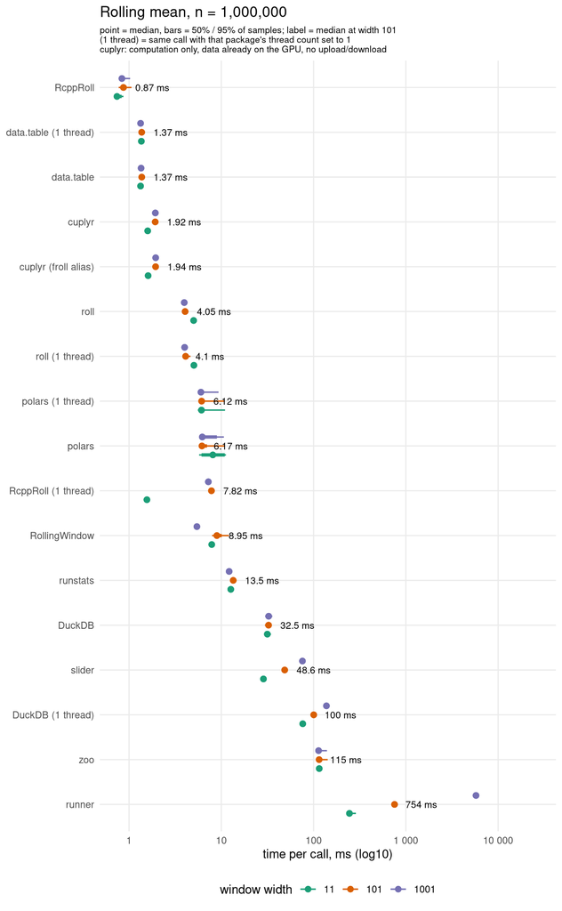

### median (median ms (IQR) n=samples)

| function | w=11 | w=101 | w=1001 |
| --- | --- | --- | --- |
| RcppRoll | 2.49 (2.48-2.53) n=20 | 4.35 (4.24-4.53) n=20 | 6.27 (6.21-6.34) n=20 |
| data.table | 18.9 (18.7-19.2) n=20 | 19.2 (19.0-19.3) n=20 | 20.1 (20.1-20.3) n=20 |
| DuckDB | 35.3 (34.3-35.9) n=20 | 43.9 (41.2-45.5) n=20 | 65.6 (63.8-68.1) n=20 |
| data.table (1 thread) | 27.9 (27.7-28.1) n=20 | 44.7 (44.4-45.0) n=20 | 65.0 (64.4-65.8) n=20 |
| polars (1 thread) | 41.9 (41.6-42.4) n=20 | 45.2 (44.8-47.4) n=20 | 46.0 (45.5-46.3) n=20 |
| polars | 43.4 (42.0-44.7) n=20 | 48.2 (47.8-49.2) n=20 | 46.2 (46.0-46.8) n=20 |
| RollingWindow | 35.9 (35.0-36.1) n=20 | 52.0 (51.7-52.3) n=20 | 65.4 (64.9-66.3) n=20 |
| RcppRoll (1 thread) | 35.3 (34.9-35.7) n=20 | 64.5 (64.1-65.3) n=20 | 92.6 (92.0-93.5) n=20 |
| zoo | 130 (129-131) n=20 | 140 (140-141) n=20 | 157 (156-158) n=20 |
| roll | 127 (125-127) n=20 | 203 (193-206) n=20 | 251 (250-252) n=20 |
| roll (1 thread) | 125 (124-126) n=20 | 207 (201-210) n=20 | 249 (249-250) n=20 |
| DuckDB (1 thread) | 265 (263-266) n=20 | 361 (357-364) n=20 | 627 (622-634) n=20 |
| cuplyr | not timed: no GPU path (cuplyr’s roll_median() runs on the CPU fallback; cudf 25.12 has no rolling MEDIAN) | not timed | not timed |

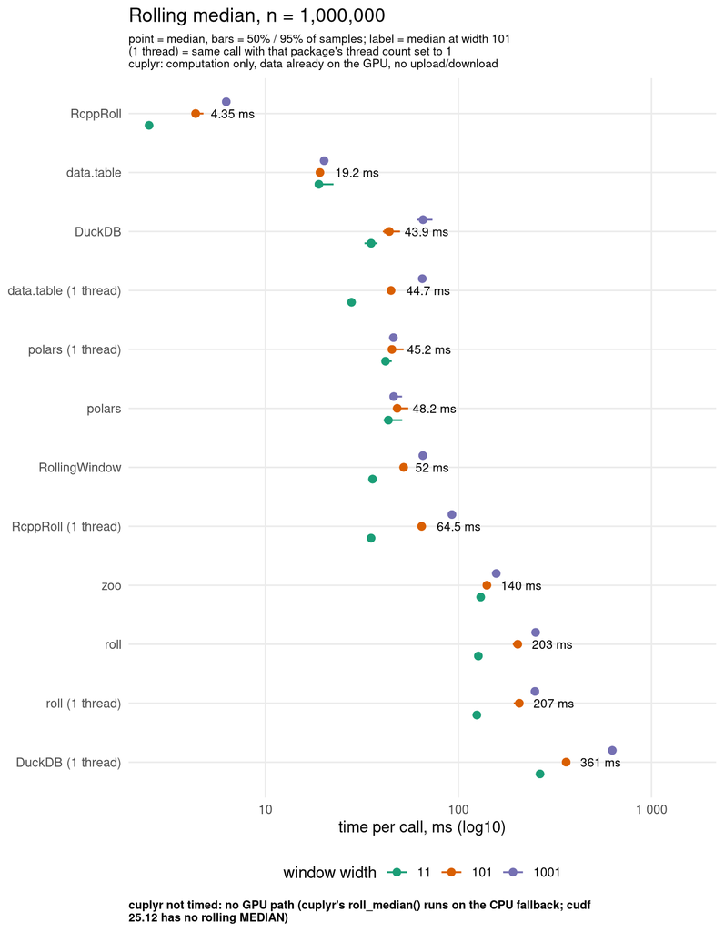

### min (median ms (IQR) n=samples)

| function | w=11 | w=101 | w=1001 |
| --- | --- | --- | --- |
| RcppRoll | 0.761 (0.746-0.826) n=20 | 0.957 (0.941-0.996) n=20 | 0.999 (0.984-1.07) n=20 |
| cuplyr | 1.53 (1.52-1.54) n=20 | 1.84 (1.84-1.85) n=20 | 1.85 (1.84-1.86) n=20 |
| cuplyr (froll alias) | 1.54 (1.53-1.55) n=20 | 1.85 (1.84-1.87) n=20 | 1.86 (1.83-1.89) n=20 |
| data.table | 3.33 (3.33-3.37) n=20 | 2.32 (2.30-2.36) n=20 | 1.96 (1.95-1.99) n=20 |
| data.table (1 thread) | 3.39 (3.36-3.44) n=20 | 2.33 (2.28-2.36) n=20 | 1.99 (1.96-1.99) n=20 |
| roll | 10.4 (10.3-10.5) n=20 | 10.4 (10.3-10.6) n=20 | 10.4 (10.3-10.6) n=20 |
| roll (1 thread) | 10.4 (10.3-10.6) n=20 | 10.6 (10.5-10.8) n=20 | 10.4 (10.3-10.7) n=20 |
| RcppRoll (1 thread) | 3.51 (3.48-3.55) n=20 | 11.4 (11.1-11.5) n=20 | 12.1 (12.0-12.3) n=20 |
| polars (1 thread) | 13.8 (13.7-13.8) n=20 | 13.7 (13.6-14.0) n=20 | 13.8 (13.6-14.0) n=20 |
| polars | 13.7 (13.6-13.8) n=20 | 13.7 (13.6-13.8) n=20 | 13.5 (13.4-13.8) n=20 |
| RollingWindow | 15.6 (15.4-15.8) n=20 | 18.2 (18.0-18.3) n=20 | 15.3 (15.1-15.4) n=20 |
| DuckDB | 31.4 (30.2-32.3) n=20 | 32.9 (32.0-33.9) n=20 | 39.9 (39.2-40.5) n=20 |
| slider | 27.6 (27.4-27.7) n=20 | 52.7 (52.1-53.3) n=20 | 69.5 (68.7-70.2) n=20 |
| DuckDB (1 thread) | 78.2 (77.7-78.6) n=20 | 107 (105-107) n=20 | 275 (273-278) n=20 |
| runner | 224 (223-236) n=20 | 433 (428-449) n=20 | 2260 (2240-2280) n=8 |

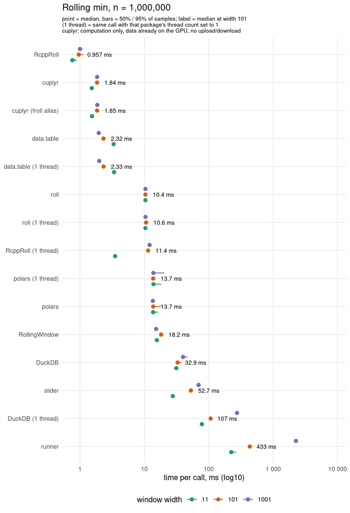

### max (median ms (IQR) n=samples)

| function | w=11 | w=101 | w=1001 |
| --- | --- | --- | --- |
| RcppRoll | 0.730 (0.717-0.761) n=20 | 0.985 (0.946-1.01) n=20 | 0.995 (0.977-1.04) n=20 |
| cuplyr | 1.54 (1.52-1.55) n=20 | 1.84 (1.83-1.86) n=20 | 1.84 (1.83-1.85) n=20 |
| cuplyr (froll alias) | 1.55 (1.54-1.57) n=20 | 1.86 (1.85-1.88) n=20 | 1.85 (1.84-1.86) n=20 |
| data.table (1 thread) | 3.43 (3.42-3.45) n=20 | 2.33 (2.29-2.34) n=20 | 1.97 (1.97-1.99) n=20 |
| data.table | 3.42 (3.37-3.45) n=20 | 2.37 (2.33-2.37) n=20 | 1.94 (1.91-1.97) n=20 |
| roll | 10.7 (10.6-10.8) n=20 | 10.4 (10.3-10.5) n=20 | 10.5 (10.5-10.6) n=20 |
| roll (1 thread) | 10.7 (10.6-10.8) n=20 | 10.6 (10.5-10.7) n=20 | 10.4 (10.3-10.5) n=20 |
| RcppRoll (1 thread) | 3.55 (3.50-3.59) n=20 | 11.2 (11.1-11.3) n=20 | 11.9 (11.7-12.0) n=20 |
| polars (1 thread) | 13.7 (13.5-13.9) n=20 | 13.7 (13.5-14.0) n=20 | 13.5 (13.3-13.9) n=20 |
| polars | 14.8 (13.6-16.4) n=20 | 13.8 (13.6-13.9) n=20 | 14.1 (13.3-18.0) n=20 |
| RollingWindow | 15.4 (15.4-15.6) n=20 | 15.2 (15.1-15.3) n=20 | 15.0 (14.9-15.3) n=20 |
| DuckDB | 31.6 (30.7-32.4) n=20 | 32.1 (31.6-33.1) n=20 | 40.3 (39.4-41.4) n=20 |
| slider | 29.2 (28.9-29.7) n=20 | 54.4 (53.7-54.9) n=20 | 68.5 (68.1-69.2) n=20 |
| DuckDB (1 thread) | 77.3 (76.6-77.5) n=20 | 107 (105-107) n=20 | 275 (273-278) n=20 |
| runner | 225 (222-235) n=20 | 449 (444-461) n=20 | 2420 (2420-2460) n=8 |
| zoo | 460 (458-466) n=20 | 451 (447-455) n=20 | 455 (451-457) n=20 |

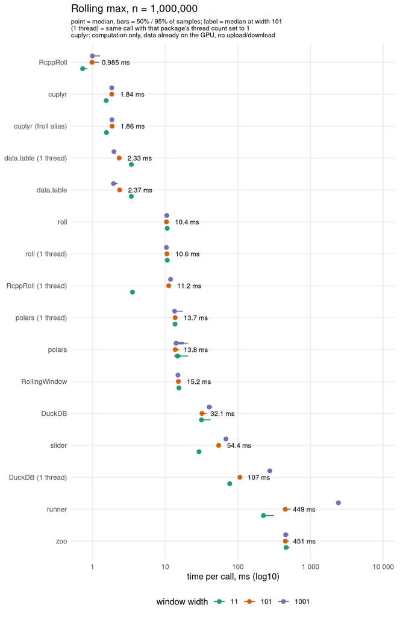

### sum (median ms (IQR) n=samples)

| function | w=11 | w=101 | w=1001 |
| --- | --- | --- | --- |
| RcppRoll | 0.692 (0.678-0.740) n=20 | 0.831 (0.806-0.890) n=20 | 0.867 (0.841-0.893) n=20 |
| data.table | 1.33 (1.32-1.33) n=20 | 1.34 (1.34-1.37) n=20 | 1.34 (1.32-1.34) n=20 |
| data.table (1 thread) | 1.34 (1.32-1.34) n=20 | 1.36 (1.34-1.37) n=20 | 1.34 (1.32-1.35) n=20 |
| cuplyr | 1.58 (1.57-1.59) n=20 | 1.92 (1.90-1.93) n=20 | 1.93 (1.92-1.94) n=20 |
| cuplyr (froll alias) | 1.58 (1.58-1.59) n=20 | 1.92 (1.91-1.94) n=20 | 1.94 (1.93-1.95) n=20 |
| roll | 3.09 (3.03-3.24) n=20 | 3.10 (3.08-3.15) n=20 | 3.14 (3.10-3.17) n=20 |
| roll (1 thread) | 3.08 (3.04-3.13) n=20 | 3.11 (3.08-3.14) n=20 | 3.18 (3.11-3.27) n=20 |
| RollingWindow | 5.36 (5.32-5.40) n=20 | 5.49 (5.45-5.52) n=20 | 5.38 (5.35-5.41) n=20 |
| polars | 5.90 (5.74-7.30) n=20 | 5.88 (5.73-6.18) n=20 | 5.83 (5.75-5.94) n=20 |
| polars (1 thread) | 6.64 (5.79-8.89) n=20 | 5.95 (5.67-7.08) n=20 | 6.08 (5.73-7.82) n=20 |
| RcppRoll (1 thread) | 1.40 (1.39-1.42) n=20 | 7.70 (7.63-7.73) n=20 | 7.31 (7.24-7.34) n=20 |
| data.table (exact) | 1.14 (1.08-1.21) n=20 | 7.77 (7.74-7.80) n=20 | 63.6 (62.3-65.4) n=20 |
| DuckDB | 31.2 (29.6-32.1) n=20 | 31.9 (31.5-33.5) n=20 | 32.7 (31.6-33.5) n=20 |
| data.table (exact, 1 thread) | 4.49 (4.43-4.52) n=20 | 38.3 (38.2-38.9) n=20 | 573 (569-575) n=20 |
| slider | 28.9 (28.8-29.3) n=20 | 49.3 (47.6-49.5) n=20 | 78.9 (77.6-79.3) n=20 |
| DuckDB (1 thread) | 71.5 (71.1-72.3) n=20 | 94.8 (94.5-95.7) n=20 | 130 (128-130) n=20 |
| zoo | 120 (119-122) n=20 | 117 (117-118) n=20 | 118 (117-120) n=20 |
| runner | 252 (248-264) n=20 | 790 (786-802) n=20 | 6340 (6330-6340) n=3 |

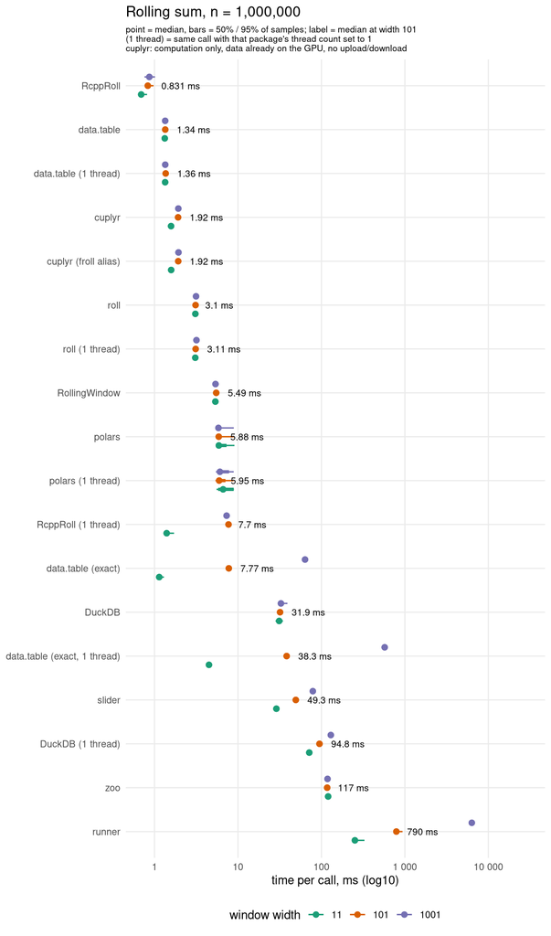

### sd (median ms (IQR) n=samples)

| function | w=11 | w=101 | w=1001 |
| --- | --- | --- | --- |
| RcppRoll | 1.27 (1.17-1.30) n=20 | 1.05 (1.03-1.06) n=20 | 1.07 (1.06-1.12) n=20 |
| cuplyr (froll alias) | 2.60 (2.59-2.61) n=20 | 2.58 (2.57-2.60) n=20 | 2.61 (2.59-2.63) n=20 |
| cuplyr | 2.58 (2.57-2.60) n=20 | 2.58 (2.56-2.59) n=20 | 2.57 (2.56-2.59) n=20 |
| RollingWindow | 7.34 (7.28-7.44) n=20 | 7.35 (7.30-7.39) n=20 | 7.32 (7.25-7.35) n=20 |
| RcppRoll (1 thread) | 10.4 (10.2-10.4) n=20 | 10.1 (9.90-10.3) n=20 | 10.4 (10.2-10.5) n=20 |
| data.table (1 thread) | 11.0 (11.0-11.0) n=20 | 10.6 (10.5-10.6) n=20 | 10.8 (10.8-11.0) n=20 |
| data.table | 11.0 (11.0-11.0) n=20 | 10.6 (10.6-10.8) n=20 | 10.7 (10.6-10.8) n=20 |
| polars | 12.7 (12.4-13.1) n=20 | 12.9 (12.6-13.1) n=20 | 12.8 (12.7-13.3) n=20 |
| polars (1 thread) | 13.1 (12.7-16.5) n=20 | 13.6 (12.6-17.2) n=20 | 12.9 (12.8-13.2) n=20 |
| roll (1 thread) | 23.2 (23.1-23.4) n=20 | 22.9 (22.8-23.0) n=20 | 23.3 (23.1-23.5) n=20 |
| roll | 23.3 (23.1-23.4) n=20 | 23.2 (22.7-23.4) n=20 | 23.2 (23.1-23.5) n=20 |
| runstats | 32.0 (31.7-32.2) n=20 | 32.0 (31.8-32.2) n=20 | 31.9 (31.7-32.0) n=20 |
| DuckDB | 33.2 (32.5-33.7) n=20 | 33.2 (31.9-34.1) n=20 | 40.9 (40.0-42.6) n=20 |
| DuckDB (1 thread) | 105 (104-106) n=20 | 159 (158-160) n=20 | 322 (320-322) n=20 |

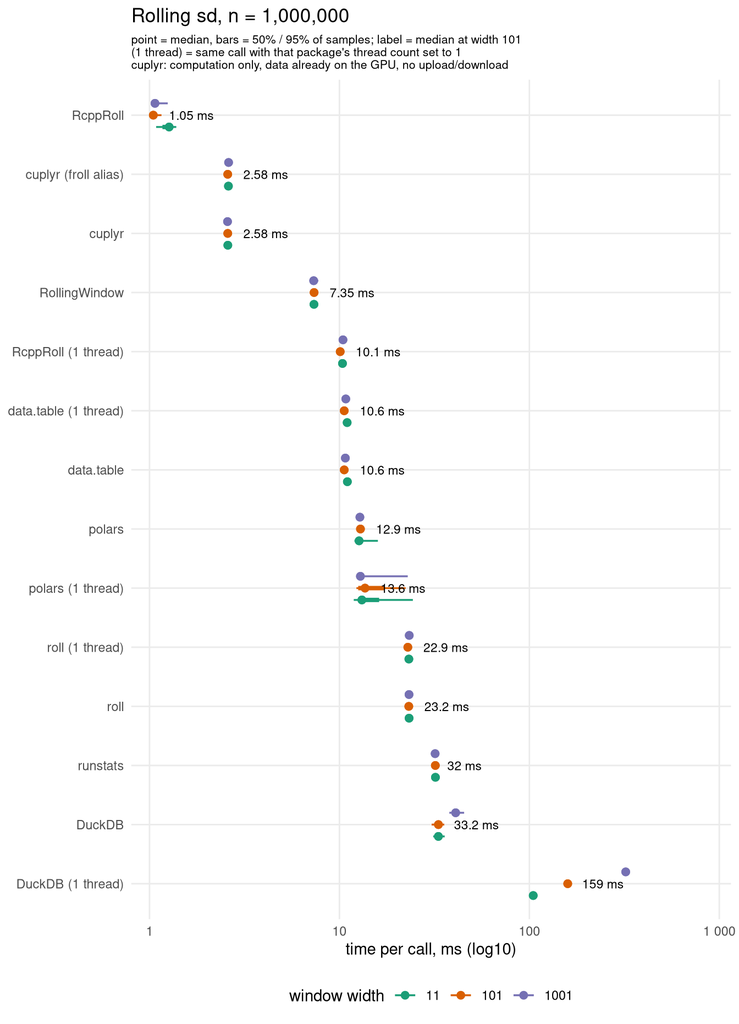

### custom (median ms (IQR) n=samples)

| function | w=11 | w=101 | w=1001 |
| --- | --- | --- | --- |
| data.table::frollapply | 1280 (1270-1280) n=5 | 1260 (1260-1280) n=5 | 1340 (1340-1360) n=5 |
| data.table::frollapply (1 thread) | 2080 (2070-2110) n=5 | 2090 (2090-2100) n=5 | 2700 (2700-2710) n=5 |
| zoo::rollapply | 3720 (3680-3770) n=5 | 5150 (5110-5190) n=4 | 13500 (13500-13500) n=1 |

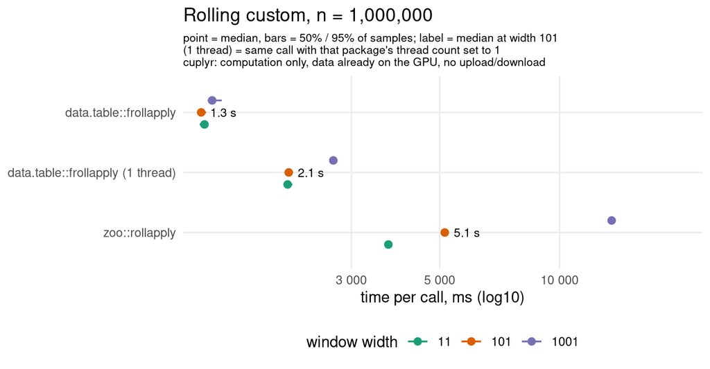

### `times` cuts (every cell not at the configured 20 / 5)

Generated from the `note` column of `timings.csv`. Each cell’s cold probe call is **not recorded**; the samples listed are the timed calls after the warmup.

| stat | fn | width | times | note |
| --- | --- | --- | --- | --- |
| mean | runner | 1001 | 3 | times cut 20 -> 3 (cold probe call 5.7 s, not recorded; 1 untimed warmup call(s); 3 timed call(s), all recorded) |
| min | runner | 1001 | 8 | times cut 20 -> 8 (cold probe call 2.2 s, not recorded; 2 untimed warmup call(s); 8 timed call(s), all recorded) |
| max | runner | 1001 | 8 | times cut 20 -> 8 (cold probe call 2.5 s, not recorded; 2 untimed warmup call(s); 8 timed call(s), all recorded) |
| sum | runner | 1001 | 3 | times cut 20 -> 3 (cold probe call 6.3 s, not recorded; 1 untimed warmup call(s); 3 timed call(s), all recorded) |
| custom | zoo::rollapply | 101 | 4 | times cut 5 -> 4 (cold probe call 4.9 s, not recorded; 2 untimed warmup call(s); 4 timed call(s), all recorded) |
| custom | zoo::rollapply | 1001 | 1 | times cut 5 -> 1 (cold probe call 13.4 s, not recorded; 1 untimed warmup call(s); 1 timed call(s), all recorded) |

Six of the 285 cells were cut; everything else ran the full number of samples (20 for the statistics, 5 for the custom functions).

## Correctness

Every timed (statistic x function x width) cell, including every timed cuplyr entry, every one-thread control and every polars and DuckDB cell (72 of them, all matching), was compared with data.table’s result. Reference: `frollmean/frollmedian/frollmin/frollmax/frollsum/frollsd`, and `frollsum` for the custom sum.

285 of 285 (function x width) cells match data.table (all.equal tol 1e-08, same NA positions). The denominator counts the cells that were timed. Three planned cells were skipped as CPU fallbacks and are neither timed nor checked, so the count is 285, not 288.

No cuplyr mismatch, and none for any other package. “Match” includes the leading `NA` padding after normalization (runstats after the right-alignment shift in `rw_normalize()`); a padding or sd-convention difference would have shown up as a mismatch. Not covered: data with `NA`s, `na.rm = TRUE`, non-default alignment.

**Edge semantics of polars and DuckDB.** Where an engine differs from data.table by definition, the benchmark either makes the result equal or keeps the difference out of what is compared:

- DuckDB’s `ROWS BETWEEN n - 1 PRECEDING AND CURRENT ROW` frame is partial at the start of the table (and of each group): it holds fewer than `n` rows, and DuckDB aggregates them where data.table has `NA`. The timed SQL guards the aggregate and returns NULL until the window is full, so the padding is the same as data.table’s, and the check above compares it.
- polars returns null for an incomplete window, because `min_samples` defaults to the window size; the null positions are data.table’s `NA` positions.
- The standard deviation is the sample standard deviation (`ddof = 1`) in all three: `STDDEV_SAMP`, `rolling_std` and `frollsd`.
- For an even window the median is the average of the two middle values in all three. Only odd widths are timed here (11 / 101 / 1001); the tests of the helpers in `bench/rolling-lib.R` check an even width as well.
- With `NA` in the input the engines differ: DuckDB’s aggregates skip NULLs, so a window holding `NA`s still has a value once it holds enough non-null values (at least one for the mean, sum, min, max and median, at least two for the standard deviation), where polars and data.table give `NA` for any window that holds one. This data has no `NA`, so that difference is not exercised, and it would have to be handled before any comparison on data with missing values.

## Extension: where the GPU should help

Rolling mean, 10 samples per cell (no cuts). `peak_gpu_MB` is the peak from `cuplyr:::gpu_alloc_tracking()` around one untimed call; `held_after_MB` is what was still held when that call returned (see F1). `correct` compares with data.table’s output. All cuplyr numbers here are computation only, data already on the GPU.

Two experiments: (a) grouped: 1e6 rows, 1e3 interleaved groups, w = 101; (b) ungrouped: 1e7 rows, w = 11 / 101 / 1001.

| experiment | fn | width | n_rows | median_ms | IQR | times | peak_gpu_MB | held_after_MB | correct | note |
| --- | --- | --- | --- | --- | --- | --- | --- | --- | --- | --- |
| grouped mean | cuplyr | 101 | 1e6 | 2.27 | 2.26-2.27 | 10 | 36 | 8 | TRUE |  |
| grouped mean | data.table (by = g) | 101 | 1e6 | 29.8 | 29.4-30.3 | 10 |  |  | TRUE |  |
| grouped mean | data.table (by = g, 1 thread) | 101 | 1e6 | 28.8 | 28.6-29.1 | 10 |  |  | TRUE |  |
| grouped mean | slider (grouped_df) | 101 | 1e6 | 54.8 | 54.2-55.1 | 10 |  |  | TRUE |  |
| grouped mean | DuckDB | 101 | 1e6 | 29.6 | 29.0-29.9 | 10 |  |  | TRUE |  |
| grouped mean | DuckDB (1 thread) | 101 | 1e6 | 170 | 170-171 | 10 |  |  | TRUE |  |
| grouped mean | polars | 101 | 1e6 | 12.9 | 12.7-13.7 | 10 |  |  | TRUE |  |
| grouped mean | polars (1 thread) | 101 | 1e6 | 19.2 | 19.1-19.3 | 10 |  |  | TRUE |  |
| 1e7 ungrouped mean | cuplyr | 11 | 1e7 | 3.47 | 3.44-3.48 | 10 | 241 | 81 | TRUE |  |
| 1e7 ungrouped mean | data.table | 11 | 1e7 | 18.2 | 18.1-18.4 | 10 |  |  | TRUE |  |
| 1e7 ungrouped mean | data.table (1 thread) | 11 | 1e7 | 18.1 | 18.0-18.3 | 10 |  |  | TRUE |  |
| 1e7 ungrouped mean | roll | 11 | 1e7 | 49.0 | 48.6-49.6 | 10 |  |  | TRUE |  |
| 1e7 ungrouped mean | roll (1 thread) | 11 | 1e7 | 48.5 | 48.4-48.9 | 10 |  |  | TRUE |  |
| 1e7 ungrouped mean | RcppRoll | 11 | 1e7 | 9.48 | 9.45-9.58 | 10 |  |  | TRUE |  |
| 1e7 ungrouped mean | RcppRoll (1 thread) | 11 | 1e7 | 20.2 | 20.1-20.3 | 10 |  |  | TRUE |  |
| 1e7 ungrouped mean | DuckDB | 11 | 1e7 | 265 | 259-270 | 10 |  |  | TRUE |  |
| 1e7 ungrouped mean | DuckDB (1 thread) | 11 | 1e7 | 804 | 801-809 | 10 |  |  | TRUE |  |
| 1e7 ungrouped mean | polars | 11 | 1e7 | 48.4 | 47.9-49.7 | 10 |  |  | TRUE |  |
| 1e7 ungrouped mean | polars (1 thread) | 11 | 1e7 | 49.2 | 48.7-49.6 | 10 |  |  | TRUE |  |
| 1e7 ungrouped mean | cuplyr | 101 | 1e7 | 6.29 | 6.27-6.30 | 10 | 530 | 81 | TRUE |  |
| 1e7 ungrouped mean | data.table | 101 | 1e7 | 18.2 | 18.2-18.2 | 10 |  |  | TRUE |  |
| 1e7 ungrouped mean | data.table (1 thread) | 101 | 1e7 | 18.3 | 18.2-18.4 | 10 |  |  | TRUE |  |
| 1e7 ungrouped mean | roll | 101 | 1e7 | 48.3 | 48.0-48.7 | 10 |  |  | TRUE |  |
| 1e7 ungrouped mean | roll (1 thread) | 101 | 1e7 | 48.5 | 48.2-48.8 | 10 |  |  | TRUE |  |
| 1e7 ungrouped mean | RcppRoll | 101 | 1e7 | 11.6 | 11.5-11.9 | 10 |  |  | TRUE |  |
| 1e7 ungrouped mean | RcppRoll (1 thread) | 101 | 1e7 | 81.9 | 81.7-82.3 | 10 |  |  | TRUE |  |
| 1e7 ungrouped mean | DuckDB | 101 | 1e7 | 262 | 254-266 | 10 |  |  | TRUE |  |
| 1e7 ungrouped mean | DuckDB (1 thread) | 101 | 1e7 | 1060 | 1050-1060 | 10 |  |  | TRUE |  |
| 1e7 ungrouped mean | polars | 101 | 1e7 | 49.5 | 49.1-50.3 | 10 |  |  | TRUE |  |
| 1e7 ungrouped mean | polars (1 thread) | 101 | 1e7 | 49.9 | 49.3-50.3 | 10 |  |  | TRUE |  |
| 1e7 ungrouped mean | cuplyr | 1001 | 1e7 | 6.27 | 6.25-6.27 | 10 | 530 | 81 | TRUE |  |
| 1e7 ungrouped mean | data.table | 1001 | 1e7 | 18.1 | 18.1-18.1 | 10 |  |  | TRUE |  |
| 1e7 ungrouped mean | data.table (1 thread) | 1001 | 1e7 | 18.0 | 18.0-18.1 | 10 |  |  | TRUE |  |
| 1e7 ungrouped mean | roll | 1001 | 1e7 | 47.9 | 47.6-48.0 | 10 |  |  | TRUE |  |
| 1e7 ungrouped mean | roll (1 thread) | 1001 | 1e7 | 48.3 | 48.1-48.8 | 10 |  |  | TRUE |  |
| 1e7 ungrouped mean | RcppRoll | 1001 | 1e7 | 11.6 | 11.5-11.7 | 10 |  |  | TRUE |  |
| 1e7 ungrouped mean | RcppRoll (1 thread) | 1001 | 1e7 | 77.6 | 77.3-78.6 | 10 |  |  | TRUE |  |
| 1e7 ungrouped mean | DuckDB | 1001 | 1e7 | 276 | 272-281 | 10 |  |  | TRUE |  |
| 1e7 ungrouped mean | DuckDB (1 thread) | 1001 | 1e7 | 1420 | 1400-1430 | 10 |  |  | TRUE |  |
| 1e7 ungrouped mean | polars | 1001 | 1e7 | 48.4 | 48.1-48.9 | 10 |  |  | TRUE |  |
| 1e7 ungrouped mean | polars (1 thread) | 1001 | 1e7 | 48.8 | 48.6-49.1 | 10 |  |  | TRUE |  |

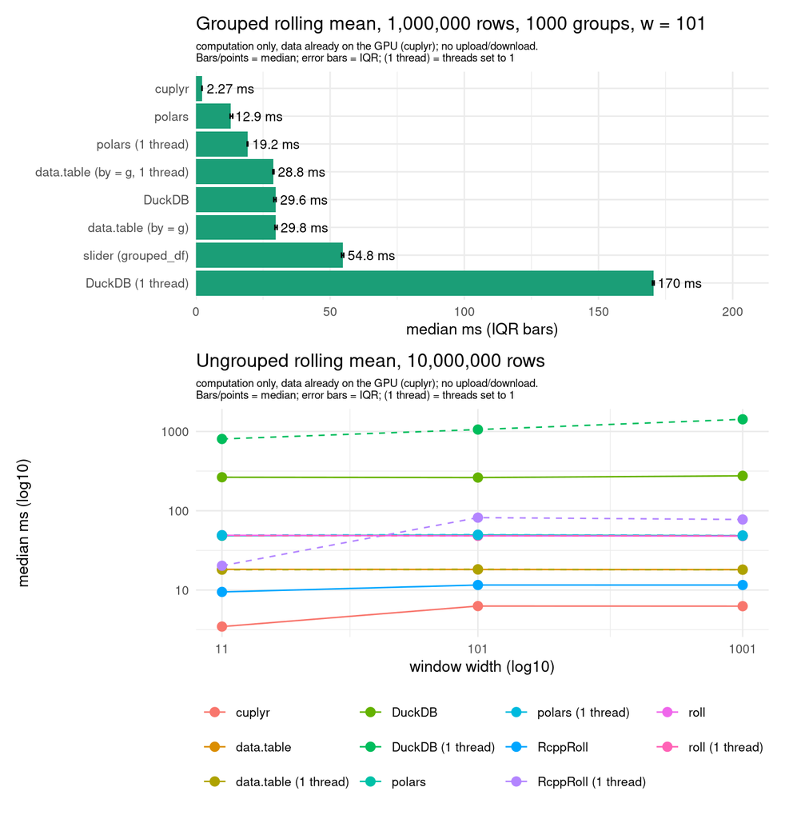

cuplyr grouped is `group_by(tbl_gpu(df), g)` built outside timing, then `compute(mutate(gtg, r = roll_mean(x, n)))` plus the fence, with n the grouped width (101). data.table is `dt[, r := frollmean(x, n), by = g]`, timed at the default thread setting and with `setDTthreads(1)`: **28.8 ms at one thread vs 29.8 ms by default, so its `by=` evaluation ran effectively single-threaded (it did not use the extra threads)**. slider is a grouped_df `mutate(r = slider::slide_mean(x, before = n - 1, complete = TRUE))`.

## polars and DuckDB

polars 2.0.0 and DuckDB 2.0.0 (DuckDB library v2.0.0) were added at Theo’s request (2026-10-25): the same statistics, widths and sizes as above (the 1e6-row grid, the 1e6-row grouped mean with 1e3 groups, the 1e7-row ungrouped mean), each at the engine’s default threads and at one thread. How they are timed is in “Read this first” and “Method”; they sit in the tables and plots above and in `timings.csv`, `correctness.csv` and `extension.csv` like every other entry. The thread counts in effect, read back from each engine and written to `engine-threads.csv`:

| engine | configuration | setting | threads_in_effect |
| --- | --- | --- | --- |
| DuckDB | default | (default) | 24 |
| DuckDB | 1 thread | SET threads = 1 | 1 |
| polars | default | (unset) | 24 |
| polars | 1 thread | POLARS_MAX_THREADS=1 | 1 |

### Where cuplyr wins and loses against every engine

One row per cell: the main grid (statistic x width), the grouped mean and the 1e7-row ungrouped mean. “Other entries” are every non-cuplyr entry at its default setting, the post’s packages and polars and DuckDB alike; the one-thread controls are not in this table (they are in the one below and in the threads table). The columns: `cuplyr_ms` is cuplyr’s median; `fastest_other` is the fastest other entry; `cuplyr_loses_to` lists the other entries that are faster than cuplyr by the document’s comparison words (see “Comparison words”; “slightly” is marked); `cuplyr_level_with` lists the ones level with it (within 5%, unless the interquartile ranges are disjoint); `cuplyr_beats` counts the other entries cuplyr is faster than (slightly faster included), out of all the other entries in the cell. The median rows have no cuplyr number (not timed: no GPU path), so only the fastest other entry is shown. Medians in ms.

| where | cuplyr_ms | fastest_other | cuplyr_loses_to | cuplyr_level_with | cuplyr_beats |
| --- | --- | --- | --- | --- | --- |
| mean, w=11 | 1.59 | RcppRoll (0.741) | data.table and RcppRoll | none | 8 of 10 |
| mean, w=101 | 1.92 | RcppRoll (0.870) | data.table and RcppRoll | none | 8 of 10 |
| mean, w=1001 | 1.93 | RcppRoll (0.837) | data.table and RcppRoll | none | 8 of 10 |
| sum, w=11 | 1.58 | RcppRoll (0.692) | data.table, data.table (exact) and RcppRoll | none | 7 of 10 |
| sum, w=101 | 1.92 | RcppRoll (0.831) | data.table and RcppRoll | none | 8 of 10 |
| sum, w=1001 | 1.93 | RcppRoll (0.867) | data.table and RcppRoll | none | 8 of 10 |
| min, w=11 | 1.53 | RcppRoll (0.761) | RcppRoll | none | 7 of 8 |
| min, w=101 | 1.84 | RcppRoll (0.957) | RcppRoll | none | 7 of 8 |
| min, w=1001 | 1.85 | RcppRoll (0.999) | RcppRoll | none | 7 of 8 |
| max, w=11 | 1.54 | RcppRoll (0.730) | RcppRoll | none | 8 of 9 |
| max, w=101 | 1.84 | RcppRoll (0.985) | RcppRoll | none | 8 of 9 |
| max, w=1001 | 1.84 | RcppRoll (0.995) | RcppRoll | none | 8 of 9 |
| sd, w=11 | 2.58 | RcppRoll (1.27) | RcppRoll | none | 6 of 7 |
| sd, w=101 | 2.58 | RcppRoll (1.05) | RcppRoll | none | 6 of 7 |
| sd, w=1001 | 2.57 | RcppRoll (1.07) | RcppRoll | none | 6 of 7 |
| median, w=11 | not timed | RcppRoll (2.49) | - | - | - |
| median, w=101 | not timed | RcppRoll (4.35) | - | - | - |
| median, w=1001 | not timed | RcppRoll (6.27) | - | - | - |
| grouped mean, 1e6 rows, 1e3 groups, w=101 | 2.27 | polars (12.9) | none | none | 4 of 4 |
| 1e7 ungrouped mean, w=11 | 3.47 | RcppRoll (9.48) | none | none | 5 of 5 |
| 1e7 ungrouped mean, w=101 | 6.29 | RcppRoll (11.6) | none | none | 5 of 5 |
| 1e7 ungrouped mean, w=1001 | 6.27 | RcppRoll (11.6) | none | none | 5 of 5 |

polars and DuckDB against cuplyr, as the ratio engine median / cuplyr median (above one: the engine is slower than cuplyr; below one: faster), at default threads and at one thread, per statistic at w=101, plus the grouped mean and the 1e7-row ungrouped mean:

| row | polars | DuckDB | polars (1 thread) | DuckDB (1 thread) |
| --- | --- | --- | --- | --- |
| 1e6 rows, mean, w=101 | 3.21x | 16.91x | 3.18x | 52.21x |
| 1e6 rows, sum, w=101 | 3.07x | 16.67x | 3.11x | 49.50x |
| 1e6 rows, min, w=101 | 7.45x | 17.82x | 7.44x | 58.01x |
| 1e6 rows, max, w=101 | 7.48x | 17.43x | 7.46x | 57.96x |
| 1e6 rows, sd, w=101 | 5.00x | 12.86x | 5.28x | 61.67x |
| 1e6 rows, median, w=101 | cuplyr not timed | cuplyr not timed | cuplyr not timed | cuplyr not timed |
| grouped mean, w=101 | 5.68x | 13.07x | 8.48x | 75.22x |
| 1e7 ungrouped mean, w=101 | 7.87x | 41.72x | 7.94x | 168.10x |

Against polars and DuckDB at their default threads cuplyr is faster in every one of the fifteen (statistic x width) cells; by statistic, mean, sum, min, max and sd: faster at all three widths. Grouped: cuplyr is faster at w=101. At 1e7 rows (one size): faster at all three widths. The median is left out of these counts, because cuplyr’s is not timed.

Against both engines at one thread, cuplyr is faster in every one of the fifteen (statistic x width) cells. At w=101 the ratio of engine to cuplyr over the statistics is 3.07-7.48x for polars and 12.86-17.82x for DuckDB at default threads, and 3.11-7.46x and 49.50-61.67x at one thread (below one the engine is faster than cuplyr).

At w=101 the fastest entry per statistic at default settings, all entries counted and cuplyr where it was timed, is: 24-thread RcppRoll for mean, sum, min, max, sd and median. Between the two engines at default threads: polars is faster for mean, sum, min, max and sd; DuckDB is faster for median (where one is faster, the other takes 1.1-5.4x as long). For median the two still agree within a factor of 1.25 (polars 48.2 ms, DuckDB 43.9 ms), and polars ran effectively on one thread there, so its samples can land on either kind of core (see “Core placement”): that order rests on this one run and may not hold in another.

## Per-call cost breakdown (overhead)

Measured on the same harness as everything else (gc-separated, fenced, `compute()` of an eager `mutate()`), on a 1e3-row table (kernel negligible; 50 samples) and, for contrast, on the 1e6-row table (20 samples). The per-statistic 1e3-row rolling floors are listed too.

| call | rows | median_ms_iqr | min_max_ms | n |
| --- | --- | --- | --- | --- |
| cuplyr (1e3-row overhead floor) [max] | 1,000 | 1.63 (1.62-1.65) | 1.59-1.76 | 50 |
| cuplyr (1e3-row overhead floor) [mean] | 1,000 | 1.67 (1.65-1.69) | 1.63-1.74 | 50 |
| cuplyr (1e3-row overhead floor) [min] | 1,000 | 1.61 (1.60-1.63) | 1.58-1.69 | 50 |
| cuplyr (1e3-row overhead floor) [sd] | 1,000 | 1.94 (1.92-1.95) | 1.89-2.13 | 50 |
| cuplyr (1e3-row overhead floor) [sum] | 1,000 | 1.67 (1.66-1.69) | 1.63-2.08 | 50 |
| plain mutate(y = x + 1) | 1,000 | 0.700 (0.689-0.712) | 0.672-0.745 | 50 |
| window mutate(r = cumsum(x)) | 1,000 | 1.36 (1.35-1.37) | 1.33-1.41 | 50 |
| window mutate(r = roll_mean(x, 101)) | 1,000 | 1.67 (1.66-1.68) | 1.63-1.72 | 50 |
| plain mutate(y = x + 1) | 1,000,000 | 0.686 (0.682-0.694) | 0.673-0.720 | 20 |
| window mutate(r = cumsum(x)) | 1,000,000 | 1.48 (1.47-1.50) | 1.45-1.57 | 20 |
| window mutate(r = roll_mean(x, 101)) | 1,000,000 | 1.93 (1.92-1.94) | 1.88-2.02 | 20 |

- **The about-1.7 ms floor is for window-function mutates; a plain mutate is about 0.7 ms.** At 1e3 rows: plain `mutate(y = x + 1)` 0.700 ms, `mutate(r = cumsum(x))` 1.36 ms, `mutate(r = roll_mean(x, n))` 1.67 ms (the five rolling statistics: 1.61-1.94 ms medians; all 250 samples between 1.58 and 2.13 ms). cumsum and roll_mean differ here (1.36 vs 1.67 ms), so part of the extra 1.0 ms may belong to the kernel rather than to the window-function path.
- **What the path does (read from the code, confirmed with `show_query()`).** A plain mutate is one node (`ast_mutate <- ast_source`). An eager window mutate is `ast_select <- ast_mutate <- ast_window <- ast_source` (`R/mutate.R` lines 671, 675 and 685 push the window, mutate and select nodes), and an eager call runs that chain as one execution (`push_chain()` in `R/execute.R`, F57): the nodes’ outputs share the input table’s columns instead of deep-copying them (`src/ops_window.cpp` about line 1252 passes the input columns through as shared pointers), so only the computed columns are allocated. Before F57 each node built a full table and `x` was copied three times per call. The per-node R work (node build, schema inference) is still done three times; I did not profile where the 1.0 ms goes at 1e3 rows. **GPU memory agrees: right after the call only the result is held, and it holds no copy of x** (1e7 rows, `memory-breakdown.csv`):

| call | n_rows | x_column_bytes | allocated_bytes | held_after_call_bytes | peak_bytes | held_after_gc_bytes |
| --- | --- | --- | --- | --- | --- | --- |
| window mutate(r = roll_mean(x, 101)) | 10,000,000 | 80,000,000 | 893,122,100 | 81,250,048 | 530,000,054 | 81,250,048 |
| plain mutate(y = x + 1) | 10,000,000 | 80,000,000 | 80,000,220 | 80,000,000 | 80,000,220 | 80,000,000 |
| window mutate(r = cumsum(x)) | 10,000,000 | 80,000,000 | 280,103,273 | 80,000,000 | 280,000,013 | 80,000,000 |

Right after a `roll_mean` mutate 81,250,048 B are held, and after a `gc()` the result alone holds 81,250,048 B: what is held right after the call is the result (held / result 1.0x), and nothing else awaits finalization. The result is exactly one 8-byte column of 1e7 rows plus its validity mask (80,000,000 + 1,250,048 B), the size of the new column `r`: `x` is shared with the input table, not copied. Before F57 the node chain built three tables, one per node: 161,250,048 (window output: x + `..win1..` + validity mask) + 242,500,096 (mutate output: x + `..win1..` + `r` + two masks) + 161,250,048 (select output, the result) = 565,000,192 B, reasoned from the node chain and sized from the column bytes and the padded validity mask, not measured here; the 81,250,048 B measured now are 14% of that sum. A plain mutate holds 80,000,000 B right after the call (exactly one 8-byte column of 1e7 rows, the size of the new column `y` alone) and allocates 80,000,220 B in total. One `roll_mean` mutate allocates 893,122,100 B in total while it runs (11x its result; peak 530,000,054 B) and frees all of it but the result before it returns; I did not break that transient allocation down. **The allocation cost scales with rows and is inside every 1e6 and 1e7 cuplyr timing.** At 1e6 rows the plain mutate takes 0.686 ms (-0.01 ms vs 1e3 rows), the `cumsum` window mutate 1.48 ms (+0.12 ms) and `roll_mean(x, n)` 1.93 ms (+0.26 ms). The narrow-window rolling mean (w=11, 1.59 ms in the tables above) is only 0.115 ms above the `cumsum` mutate: at narrow widths, most of cuplyr’s time at this size is the call chain and the allocations, not the rolling kernel. (This is an inference from comparing two different kernels, not a profile.)

## Conclusions (in the post’s style, updated)

All figures: 1e6 rows, width 101, median ms, computation only. cuplyr excludes transfers. Thread behaviour of the entries is the measured one in “Threads actually used”: RcppRoll ran on 24 OpenMP threads; data.table’s `frollmean/sum/min/max/sd` and its `by=` evaluation ran effectively on one thread; roll ran effectively on one thread; data.table’s `frollmedian`, `frollsum(algo = "exact")` and `frollapply` scale; polars ran effectively on one thread (one-thread / default ratio 0.94-1.06), although its pool has 24 threads; DuckDB scaled with its threads on every statistic (pool of 24; 3.0-8.2x slower at one thread).

- **The post’s headline (“data.table wins”) holds (with an exception, below) at equal, one-thread conditions; RcppRoll’s lead at default settings comes from its 24 OpenMP threads.** At default settings RcppRoll was the fastest package in every statistic: mean 0.870 ms (data.table 1.37), sum 0.831 ms (data.table 1.34), min 0.957 ms (data.table 2.32), max 0.985 ms (data.table 2.37), sd 1.05 ms (data.table 10.6), median 4.35 ms (data.table 19.2). With `RcppRoll.threads = 1` it takes mean 7.82, sum 7.70, min 11.4, max 11.2, sd 10.1 and median 64.5 ms (9-15x slower). Against that one-thread RcppRoll, data.table (whose mean/sum/min/max calls are single-threaded anyway) compares as follows, with both at one thread: mean and median: faster at all three widths; sum, min and max: slightly faster at w=11, faster at w=101 and w=1001; sd: slower at w=11, slightly slower at w=101 and w=1001. For the median, data.table at one thread takes 27.9 / 44.7 / 65.0 ms (RcppRoll at one thread: 35.3 / 64.5 / 92.6); RollingWindow’s median (35.9 / 52.0 / 65.4 ms) compared with data.table at one thread is behind at w=11 and w=101, level at w=1001. Even with its 12 threads data.table’s median (19.2 ms) is about 4.4x slower than the 24-thread RcppRoll (4.35 ms). sd is the exception: RollingWindow (7.35 ms) is fastest, then one-thread RcppRoll (10.1) and one-thread data.table (10.6); the post had no data.table sd.
- **roll** (4.05 ms mean, 3.10 sum, 10.4 min/max, 23.2 sd, 203 median) is a reasonable choice for the statistics it covers, but data.table 1.18 now has `frollmedian` and `frollsd` and beats it on those (at one thread, too: median 44.7 vs 207 ms, sd 10.6 vs 22.9). roll ran on one thread for every statistic.
- **slider (49-54 ms at w=101; 28-29 ms at w=11, 69-79 ms at w=1001, growing with the width) is for custom alignment, not speed.** zoo (115-451 ms) and runner (433-790 ms at w=101, 2.3-6.3 s at w=1001) are slow. Custom functions cost 1.26 s (`frollapply`; 2.09 s at one thread) and 3.7-14 s (`zoo::rollapply`, growing with the width) against 1.3 ms for the optimized equivalent (data.table’s `frollsum`). Avoid them.
- **Where cuplyr lands (ungrouped, 1e6 rows).** Native mean/sum/min/max take 1.5-1.6 / 1.8-1.9 / 1.8-1.9 ms at widths 11 / 101 / 1001, against a per-call floor of about 1.7 ms for window mutates (on a 1e3-row table), which exceeds the whole call at w=11 (the floor was timed in another chunk, so it is not a strict lower bound). For mean, per competitor (median at w=101 in parentheses): against data.table (1.37), data.table (1 thread) (1.37) and 24-thread RcppRoll (0.870), cuplyr is slower at all three widths; against 24-thread DuckDB (32.5), DuckDB (1 thread) (100), polars (6.17), polars (1 thread) (6.12), roll (4.05), roll (1 thread) (4.10), RollingWindow (8.95), runner (754), runstats (13.5), slider (48.6) and zoo (115), cuplyr is faster at all three widths; against RcppRoll (1 thread) (7.82), cuplyr is slightly slower at w=11, faster at w=101 and w=1001. For sum against roll, cuplyr is faster at all three widths (1.92 vs 3.10 ms at w=101). For min and max it beats data.table at every width (cuplyr vs data.table at w=11: 1.53 vs 3.33 ms for min and 1.54 vs 3.42 ms for max). cuplyr sd takes 2.58 / 2.58 / 2.57 ms; among the entries at their default settings it is second at w=11, second at w=101 and second at w=1001. cuplyr `roll_median()` is not timed: it has no GPU path and runs on the CPU fallback, so it is left out of every figure here (F3). Custom functions: not supported.
- **cuplyr’s cost does not grow strongly with the window width (mean 1.59 / 1.92 / 1.93 ms; sd 2.58 / 2.58 / 2.57 ms)** while data.table’s mean/sum/sd/median, roll’s mean/sum/min/max/sd and 24-thread RcppRoll’s mean/sum/min/max/sd are flat in the width (data.table’s min/max get faster with the width; data.table’s exact sum, roll’s median and 24-thread RcppRoll’s median get slower). That is not the pattern a kernel that rescans each window would produce. I did not read or profile the kernel (F2).
- **polars and DuckDB (added 2026-10-25), computation only, both on in-engine data.** Against polars and DuckDB at their default threads cuplyr is faster in every one of the fifteen (statistic x width) cells; by statistic, mean, sum, min, max and sd: faster at all three widths. Grouped: cuplyr is faster at w=101. At 1e7 rows (one size): faster at all three widths. The median is left out of these counts, because cuplyr’s is not timed. At w=101 the fastest entry per statistic is 24-thread RcppRoll for mean, sum, min, max, sd and median. Their one-thread controls are in the section “polars and DuckDB”.
- **Grouped data and large data, in the configurations measured here.** Grouped mean (one configuration: 1e6 rows, **1e3 groups**, w=101): cuplyr 2.27 ms vs data.table by group 29.8 ms, slider 54.8 ms, polars 12.9 ms and DuckDB 29.6 ms, so cuplyr is about 13x faster than data.table, about 24x faster than slider, about 5.7x faster than polars and about 13x faster than DuckDB, computation only. data.table’s `by=` evaluation ran effectively single-threaded (29.8 ms by default, 28.8 ms at `setDTthreads(1)`), so the 13x is the GPU against **one CPU thread making 1,000 per-group calls**, not against 12 threads. I did not vary the group count; data.table’s cost is expected to grow with the number of groups, so the ratio is specific to 1e3 groups. At 1e7 ungrouped rows (one size) cuplyr is fastest at w=11 (3.47 ms vs data.table 18.2, roll 49.0, 24-thread RcppRoll 9.48, 24-thread DuckDB 265 and polars 48.4; one-thread RcppRoll 20.2 and one-thread DuckDB 804), w=101 (6.29 ms vs data.table 18.2, roll 48.3, 24-thread RcppRoll 11.6, 24-thread DuckDB 262 and polars 49.5; one-thread RcppRoll 81.9 and one-thread DuckDB 1060) and w=1001 (6.27 ms vs data.table 18.1, roll 47.9, 24-thread RcppRoll 11.6, 24-thread DuckDB 276 and polars 48.4; one-thread RcppRoll 77.6 and one-thread DuckDB 1420). Peak GPU memory for the 1e7-row call was 530 MB, well inside 12 GB, and transient: right after the call only the 81 MB result is held (F1).
- Net: at the post’s size cuplyr is mid-pack (rank 3 of 11 entries at their default settings for mean at w=101; the one-thread controls are not ranked), and per-call cost is most of its time there (the 1e3-row floor of about 1.7 ms is 105% of its mean call at w=11 and 87% at w=101). In the larger configurations measured it was the fastest entry for the grouped configuration (1e3 groups) and 1e7 rows with windows of 11, 101 and 1001, including against 24-thread RcppRoll at 1e7 rows; that is one grouped configuration, one large size and the widths where it was fastest. All of it only when the data already lives on the GPU. On the main grid, against both polars and DuckDB at default threads cuplyr is faster in every one of the fifteen (statistic x width) cells.

## Findings (candidate backlog rows; nothing was fixed in this feature)

- **F1 (resolved by F57). Before F57 an eager window mutate materialized three full tables and held them until R’s GC.** One eager `mutate(r = roll_mean(x, n))` on 1e7 rows runs `ast_window -> ast_mutate -> ast_select` (`R/mutate.R` 671, 675, 685); in F54 each node built a new table and `src/ops_window.cpp` deep-copied every input column, so `x` was copied three times; F57 runs the chain once and shares the columns (`src/ops_window.cpp` about line 1252). In this run, right after the call 81,250,048 B are held (`gpu_alloc_tracking()`), and after a `gc()` the result alone holds 81,250,048 B (held / result 1.0x; `memory-breakdown.csv`, `memory-finding.csv`). No intermediate table outlives the call and the result holds no copy of `x`, so F1 is resolved: the remaining per-call cost has no materialization component (no table is copied and nothing beyond the result is held). While it runs, the call still allocates 893,122,100 B in total (peak 530,000,054 B) and frees all of it but the result before it returns (see “Per-call cost breakdown”). A dropped result is still freed only when R finalizes its pointer: twenty back-to-back calls without `gc()` did not run out of memory at this size on the 12 GB card.
- **F2. Rolling kernels do not slow down strongly with the window width in this run.** At 1e6 rows, from w=101 to w=1001, mean goes from 1.92 ms to 1.93 ms and sd from 2.58 ms to 2.57 ms (data.table is flat in the width: 10.7 ms for sd at w=1001). At 1e7 rows mean at w=1001 takes 6.27 ms for cuplyr vs data.table 18.1 and 24-thread RcppRoll 11.6. The widths do not show strong growth in this run, so there is no evidence of a rescan here. Candidate row (only if the growth shows up in a later run): an incremental mean/sum (prefix sums) and a Welford or sum-of-squares sd, checked against `all.equal()` at the correctness tolerance (1e-08), or find a cudf aggregation that does not rescan each window (needs a probe).
- **F3. `roll_median()`’s CPU fallback is an R loop, not measured in this report.** `roll_apply_generic` (`R/roll.R`) loops in R, and it is not timed anywhere in this report. Candidate rows: (a) cheap, call `data.table::frollmedian` (19-20 ms here at 12 threads, 28-65 ms at one thread across the three widths) inside the fallback; (b) real, a GPU rolling median (cudf 25.12 has no MEDIAN rolling aggregation).
- **F4. A fixed overhead of about 1.7 ms per eager window-function `mutate()` on a 1e3-row table (0.7 ms for a plain mutate).** About 1.0 ms of the 1.7 is specific to the window path, i.e. the ast_select <- ast_mutate <- ast_window <- ast_source chain (three nodes, run as one execution; `cumsum` costs 1.36 ms against 1.67 ms for `roll_mean`), which may include part of the kernel’s cost; the rest is the 0.7 ms every eager mutate pays. At 1e6 rows the same chain costs 1.48 ms for `cumsum` against 0.686 ms for a plain mutate, and the floor is about 105% of the narrow-window rolling cost. Since F57 this cost has no materialization component: no table is copied and nothing beyond the result is held (F1). Candidate row: profile the window path’s extra 1.0 ms (the three node builds and schema inferences in R, the lowering, the kernel launches) and the 0.7 ms every eager mutate pays (R dispatch, AST build, schema inference), since I did not.
- **F5 (minor). No documented completion semantics.** Since F57 there is a documented `gpu_sync()` that waits for the device; the verbs themselves still return once their work is queued, so wall-clock timing of cuplyr from R is only meaningful after a wait; the benchmark uses `gpu_sync()` as its fence (F57 added it; before, a one-row `gpu_head()` read did the job). Related: `x$ptr` on a `tbl_gpu` from outside the namespace returns NULL (tibble’s `$`), so helper code has to use `.subset2()`.

## How to render

This render took 6 s (knitting, from the setup chunk to the last chunk) and ran none of the timing chunks: all eight were cache hits, so none of their time is part of this render. The last complete cold render of this code took 20 min 22 s (knitting, from 20:35 to 20:55 on 2026-10-26; 20 min 27 s with Quarto and pandoc included), of which the timing chunks took 20 min 16 s. The report is published at /home/theo/cuplr/scratchpad/benchmarks/rolling/rolling-window.html.

Render only through `tools/r`, because the benchmark holds the GPU and the project has one GPU lock for every R process. From the checkout:

```
tools/r 'source("bench/rolling-window.R")'
```

That runs `quarto render` on this file with `params$root` set to the checkout, writes `rolling-window.html` and the CSVs to `params$out_dir` and keeps the knitr cache of the `bench-*` chunks in `params$cache_dir`. Quarto empties the directory given to `--output-dir` before it renders, and `params$out_dir` holds the install logs this document reads (and, by default, the cache), so the wrapper renders into a temporary directory and copies the HTML over. Do the same by hand: never pass `params$out_dir` as `--output-dir`. A cold run (empty cache) took 20 min 16 s of timed work on this machine; a render with a warm cache re-renders only the prose, tables and figures and takes seconds. A render in which every timing chunk ran also writes `render-time.csv` to `params$out_dir` (the cache key, a hash of the timing chunks’ code, the start and end of the render, the start time of each timing chunk, its knitting time and the time of the timing chunks; `bench/rolling-window.R` adds the total with Quarto and pandoc), so that a later warm render can still say what a cold render took. A warm render quotes that record only when the cache key and the code of the timing chunks are unchanged and every cached result started inside that render at the time the record gives for it; after a timing chunk is edited and rerun, the record is not quoted. Quarto 1.9.38 is used; it is a user install and is not installed or upgraded by anything here.

To try it at smoke size (a few seconds), put the overrides in a YAML file and render this file in place with `--execute-params`; the keys are the front matter’s `params`, and with the output and cache directories under `/tmp` the default cache is left alone:

```
root: "/path/to/the/checkout"
out_dir: "/tmp/rolling-out"
cache_dir: "/tmp/rolling-cache"
n_rows: 5000
times: 2
times_custom: 1
cell_budget: 1
probe_limit: 5
group_rows: 5000
n_groups: 10
ext_rows: 20000
ext_times: 2
```

```
tools/r 'system2(Sys.which("quarto"), c("render", "bench/rolling-window.qmd", "--output-dir", "/tmp/rolling-html", "--execute-params", "smoke.yml"))'
```

The test `tests/testthat/test-parity-F63-qmd-render.R` does the same on a copy of this file in a temporary directory, with a clean cache, a prose-only edit, a code edit, an edit of the helper file and a forced rerun in turn (opt in with `CUPLYR_BENCH_RENDER=1`).

**Forcing a full rerun.** Set `FULL_RERUN <- TRUE` before `source("bench/rolling-window.R")`; it passes `-P rebuild:true`, which makes the setup chunk set `cache.rebuild` for the `bench-*` chunks, so every timing chunk runs again and saves its cache anew (`rebuild` is not part of the cache key). Do the same by hand with `-P rebuild:true` (or `rebuild: true` in the parameters file), or delete the cache directory (/home/theo/cuplr/scratchpad/benchmarks/rolling/cache). Do not use `quarto render --cache-refresh`. In a review probe it re-ran none of the timing chunks, switched caching on for every other chunk, the setup chunk included, and left cache and figure directories next to the source; a later render would then restore the setup chunk from that cache instead of running it (reasoned, not run).

**What invalidates the cache.** A `bench-*` chunk reruns when any of these change: the chunk’s own code or options; the content (not the modification time) of `bench/rolling-lib.R`; the content of cuplyr’s `R/*.R` and `src/*.{cpp,cu,cuh,h,hpp}` files and of `src/Makevars` (the compile flags) under `params$root`; the version of R, of libcudf (25.12.00), of polars’ Rust crate (0.55.1) or of any package the benchmark uses (`cuplyr`, `data.table`, `roll`, `RollingWindow`, `runstats`, `slider`, `RcppRoll`, `zoo`, `runner`, `microbenchmark`, `ggdist`, `paletteer`, `ggtext`, `ggplot2`, `scales`, `patchwork`, `dplyr`, `RcppParallel`, `fftwtools`, `tibble`, `knitr`, `rmarkdown`, `polars`, `duckdb`, `DBI` and `callr`); or any run parameter other than the directories and the rebuild switch (`root`, `out_dir`, `cache_dir`, `rebuild`). Prose, tables and figures are never cached, so editing them never reruns a benchmark. The cached chunks return plain data frames only: a GPU object left in a cached chunk would be restored as a dead pointer.